# Bright spot attribute analysis

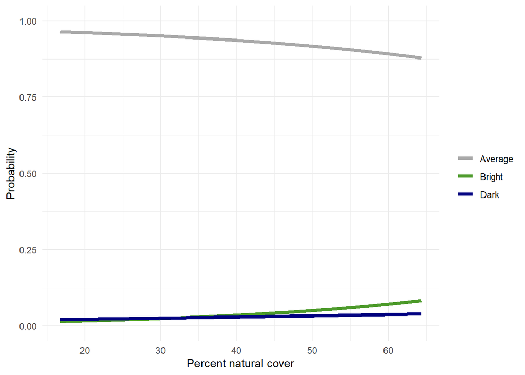

```r
prob_plot("IJI_NOMASK", xlab = "Percent natural cover")
```

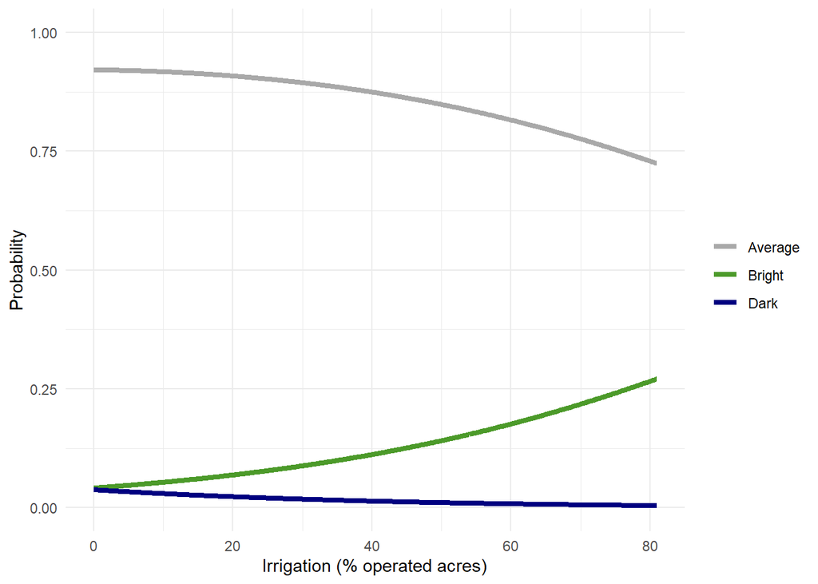

```r
prob_plot("irrig", xlab = "Irrigation (% operated acres)")
```

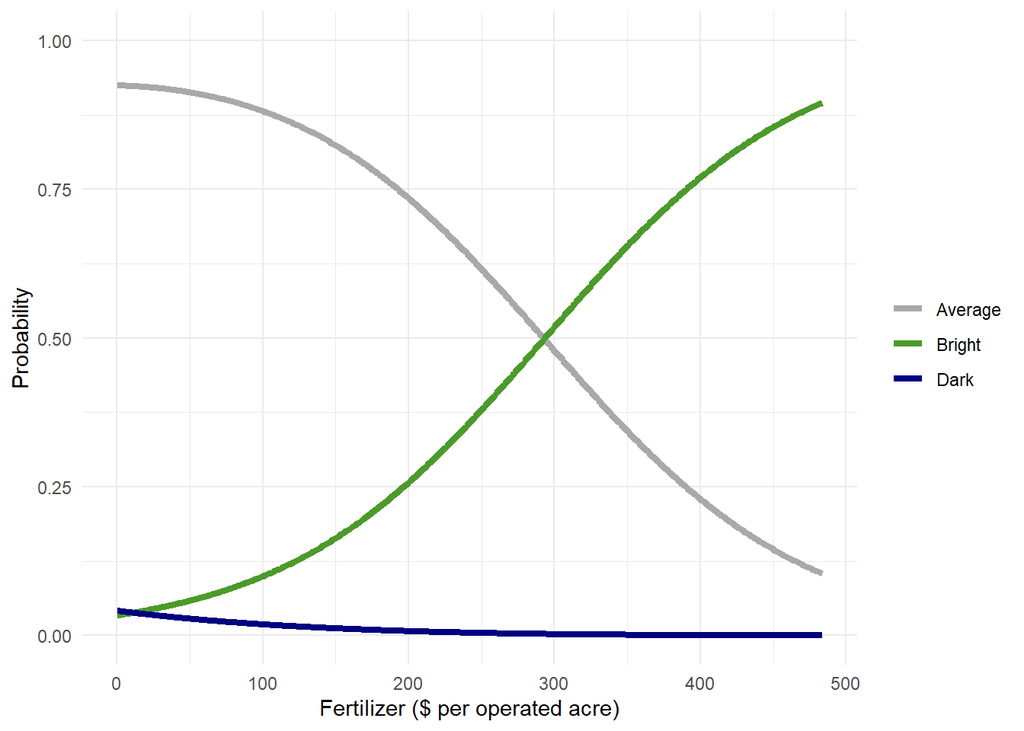

```r
prob_plot("fert", xlab = "Fertilizer ($ per operated acre)")
```

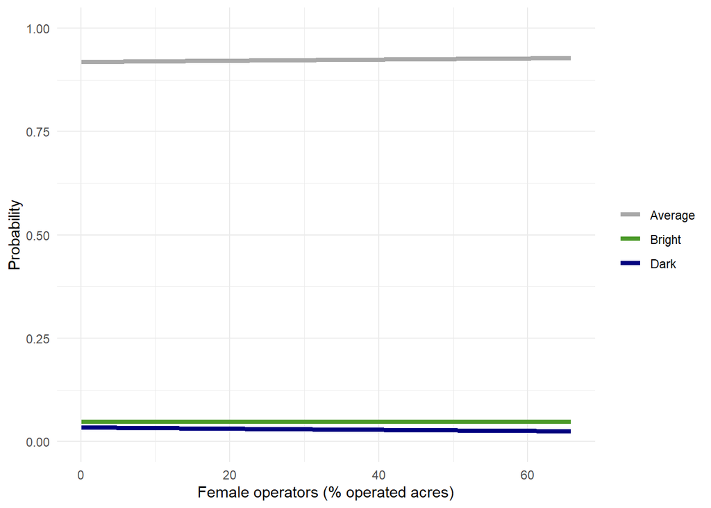

```r
prob_plot("female", xlab = "Female operators (% operated acres)")
```

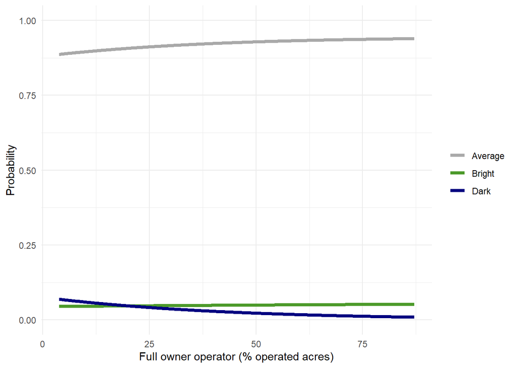

```r
prob_plot("full_owner", xlab = "Full owner operator (% operated acres)")
```

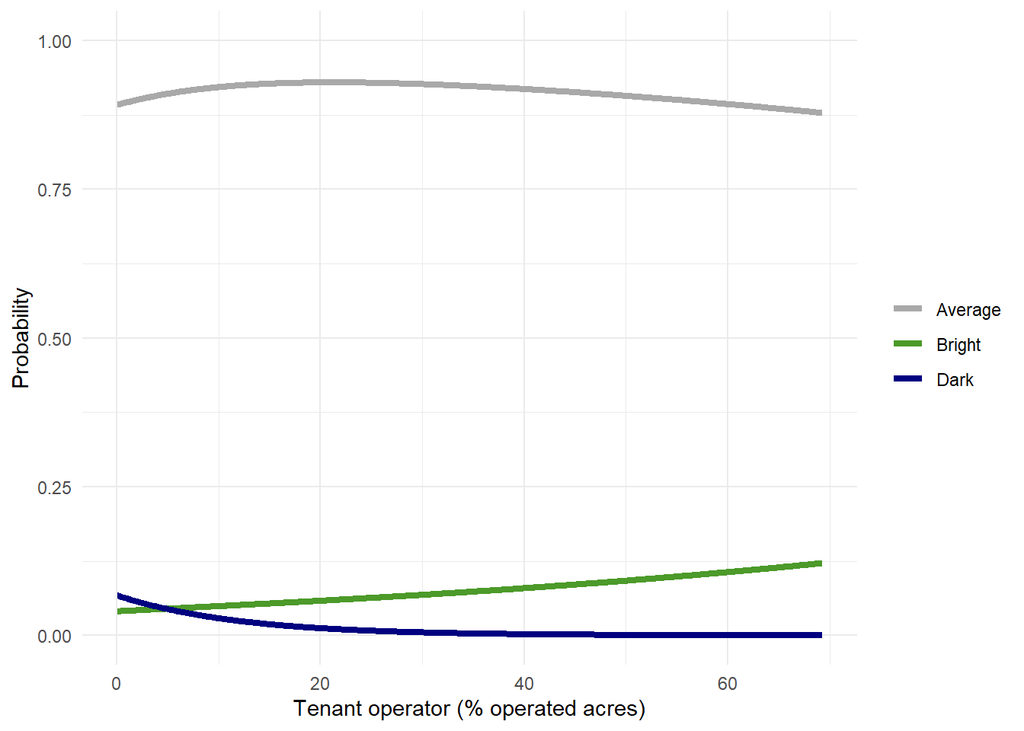

```r
prob_plot("tenant", xlab = "Tenant operator (% operated acres)")
```

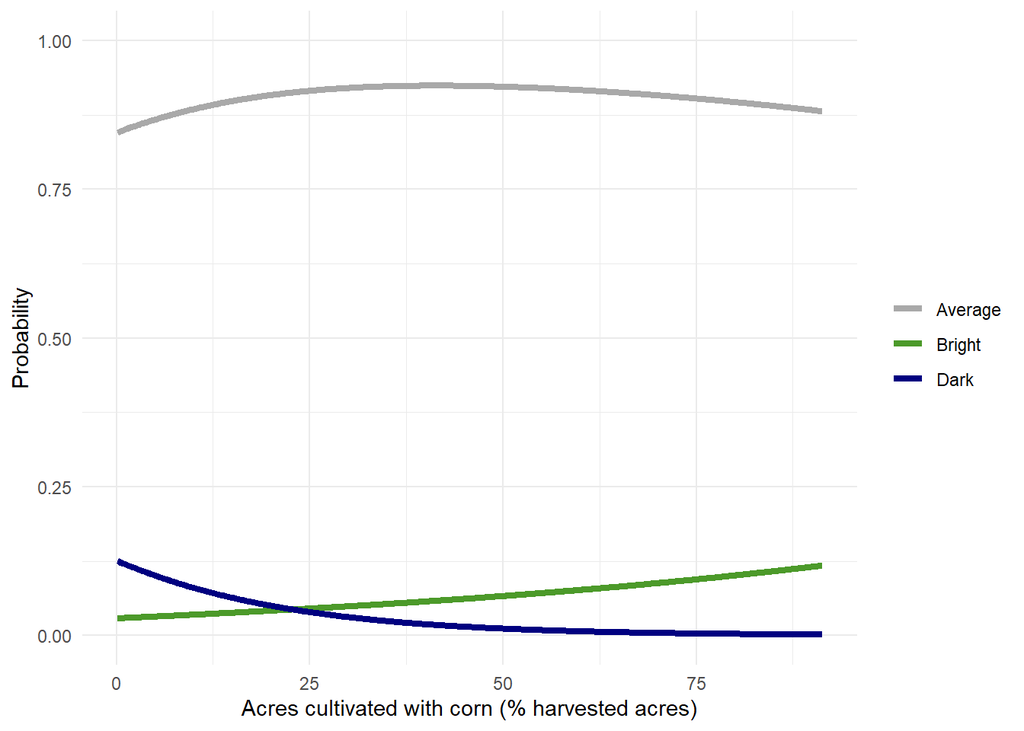

```r
prob_plot("ph_corn", xlab = "Acres cultivated with corn (% harvested acres)")
```

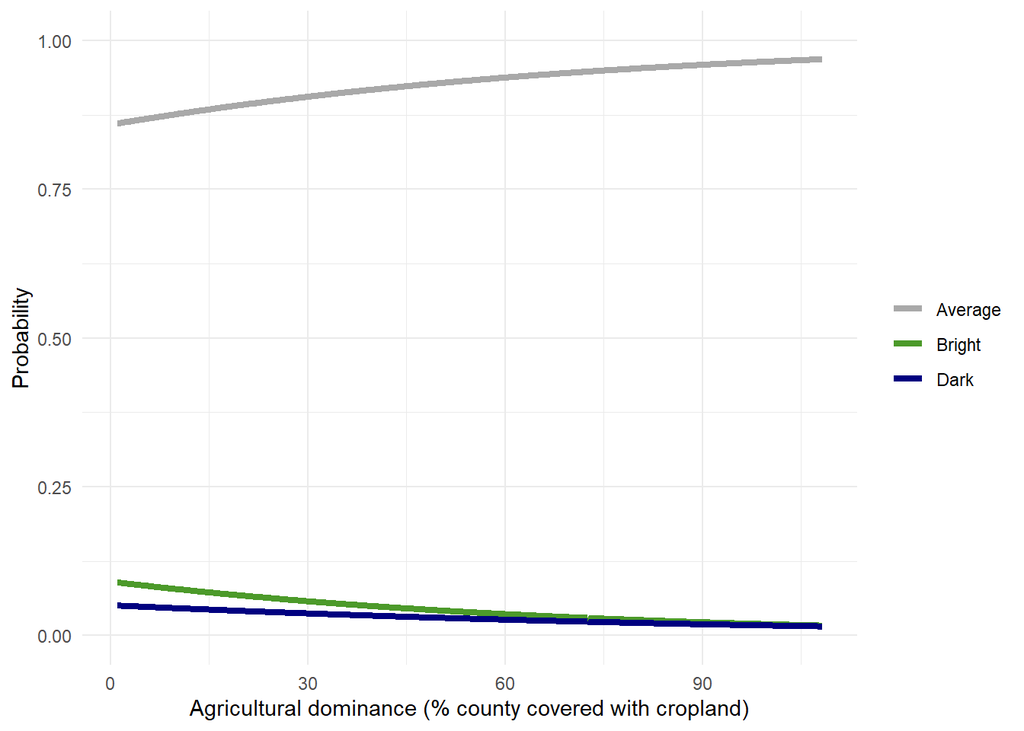

```r
prob_plot("cty_cl", xlab = "Agricultural dominance (% county covered with cropland)")
```

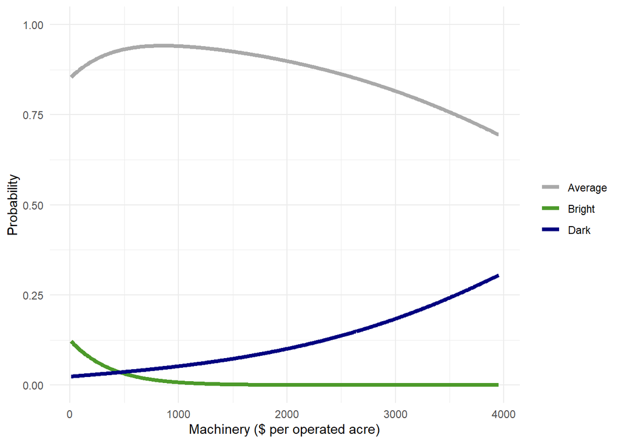

```r
prob_plot("machinery", xlab = "Machinery ($ per operated acre)")
```

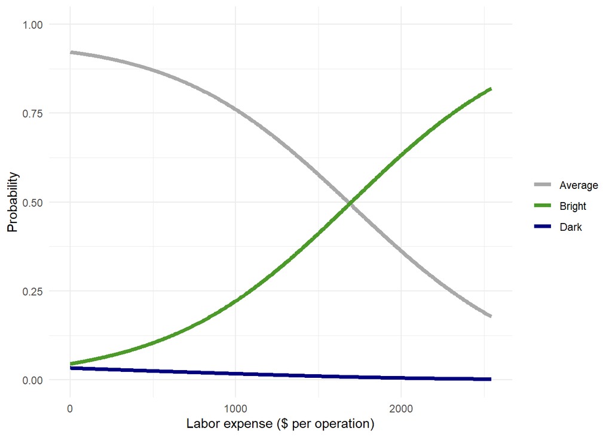

```r
prob_plot("labor_expense", xlab = "Labor expense ($ per operation)")
```

Here’s another interesting way to do the same thing, but not based on simulated data:

```r
# another interesting way to visualize results
# https://thomasleeper.com/Rcourse/Tutorials/nominalglm.html
# first create data where the VOI with simulated range of VOI
voi <- "SDI_NOMASK"
xlab <- "SDI_NOMASK"

newdata <- mlData %>% select(-c(voi)) %>% mutate(!!voi := seq(min(mlData[,voi]), max(mlData[,voi]), length.out = nrow(mlData)))

p1 <- predict(ml_out, newdata, type = "class")
p2 <- predict(ml_out, newdata, type = "probs")

plot(NA, xlim = c(min(mlData[,voi]), max(mlData[,voi])), ylim = c(0, 1), xlab = xlab, ylab = "Predicted Probability")
lines(newdata[,voi], p2[, 1], col = "red", lwd = 2)
lines(newdata[,voi], p2[, 2], col = "blue", lwd = 2)
lines(newdata[,voi], p2[, 3], col = "green", lwd = 2)
# some text labels help clarify things:
text(9, 0.75, "y==1", col = "red")
text(6, 0.4, "y==3", col = "green")
text(5, 0.15, "y==2", col = "blue")
```

### Std. Multinomial logistic

```r
# standardize data for interpretability
mlData <- as.data.frame(scale(varData %>% select(-c(BS_BIN, DS_BIN))))
# create categorical predictor
mlData$BS_CAT <- ifelse(varData$BS_BIN == 1, "Bright", NA)
mlData$BS_CAT <- ifelse(varData$DS_BIN == 1, "Dark", mlData$BS_CAT)
mlData$BS_CAT[is.na(mlData$BS_CAT)] <- "Average"
mlData$BS_CAT <- as.factor(mlData$BS_CAT)
# set baseline
mlData$BS_CAT <- relevel(mlData$BS_CAT, ref = "Average")

# build training and testing datasets
set.seed(1)
random_rn <- sample(nrow(mlData), ceiling(nrow(mlData)*.25))
ho <- mlData[random_rn,]
train <- mlData[-random_rn,]

table(mlData$BS_CAT)
```

```
##
## Average  Bright    Dark
##    7662     498     490
```

```r
library(nnet)
ml_out <- multinom(BS_CAT ~ ., data = train)
summary(ml_out)
```

```
## Call:
## multinom(formula = BS_CAT ~ ., data = train)
##
## Coefficients:
##        (Intercept)         age      female       fert full_owner
## Bright   -2.951719  0.07977178 -0.00188875  0.2974918  0.0185170
## Dark     -3.340386 -0.06451686 -0.03894545 -0.1988038 -0.3983949
##          gvt_prog      irrig labor_expense  machinery     tenant
## Bright 0.21085938  0.3314456    0.13052955 -0.6233551  0.1109381
## Dark   0.03264379 -0.3023691   -0.03405125  0.1497767 -0.6070724
##            cty_cl    ph_corn   ED_NOMASK IJI_NOMASK  LPI_NOMASK
## Bright -0.4278622  0.2701038 -0.03615377  0.2041129 -0.08950562
## Dark   -0.3115247 -0.8974086 -0.24885216  0.0784213 -0.31458692
##        RICH_NOMASK     cty_pe
## Bright -0.33287708 0.04505663
## Dark   -0.03781509 0.01046288
##
## Std. Errors:
##        (Intercept)        age     female      fert full_owner   gvt_prog
## Bright  0.06739768 0.07519643 0.07156600 0.0984110  0.1024850 0.07272272
## Dark    0.09264024 0.08471004 0.07392746 0.1514156  0.1090858 0.10167304
##             irrig labor_expense machinery     tenant    cty_cl    ph_corn
## Bright 0.05372105    0.06050022 0.1276904 0.06568648 0.1162557 0.07031526
## Dark   0.15461663    0.10295831 0.1203893 0.12140640 0.1240556 0.09971303
##        ED_NOMASK IJI_NOMASK LPI_NOMASK RICH_NOMASK     cty_pe
## Bright 0.1077022 0.07647624 0.09415891  0.07692596 0.08662608
## Dark   0.1053350 0.07480312 0.08802089  0.09333923 0.08938735
##
## Residual Deviance: 4372.159
## AIC: 4440.159
```

```r
ml_exp <- exp(coef(ml_out))
```

Wow, thanks [this post](https://www.andrewheiss.com/blog/2016/04/25/convert-logistic-regression-standard-errors-to-odds-ratios-with-r/):

```r
get.or.se <- function(model) {
  broom::tidy(model) %>%
    mutate(or = exp(estimate),
           var.diag = diag(vcov(model)),
           or.se = sqrt(or^2 * var.diag)) %>%
    select(or.se) %>% unlist %>% unname
}

se <- get.or.se(ml_out)
```

Adding significance:

```r
eff <- as.data.frame(t(ml_exp))
eff$Variable <- rownames(eff)
eff$SE_BS <- se[1:nrow(eff)]
eff$SE_DS <- se[(nrow(eff)+1):length(se)]

# add p-values, Wald test
z <- summary(ml_out)$coefficients/summary(ml_out)$standard.errors
# two tailed Z-test
p <- (1-pnorm(abs(z), 0, 1)) * 2
p <- as.data.frame(t(p))
colnames(p) <- c("Bright_P", "Dark_P")
p$Variable <- rownames(p)

eff <- merge(eff, p, by = "Variable")
eff$Bright_S <- as.factor(ifelse(eff$Bright_P > 0.05, "p > 0.05", "p < 0.05"))
eff$Dark_S <- as.factor(ifelse(eff$Dark_P > 0.05, "p > 0.05", "p < 0.05"))
```

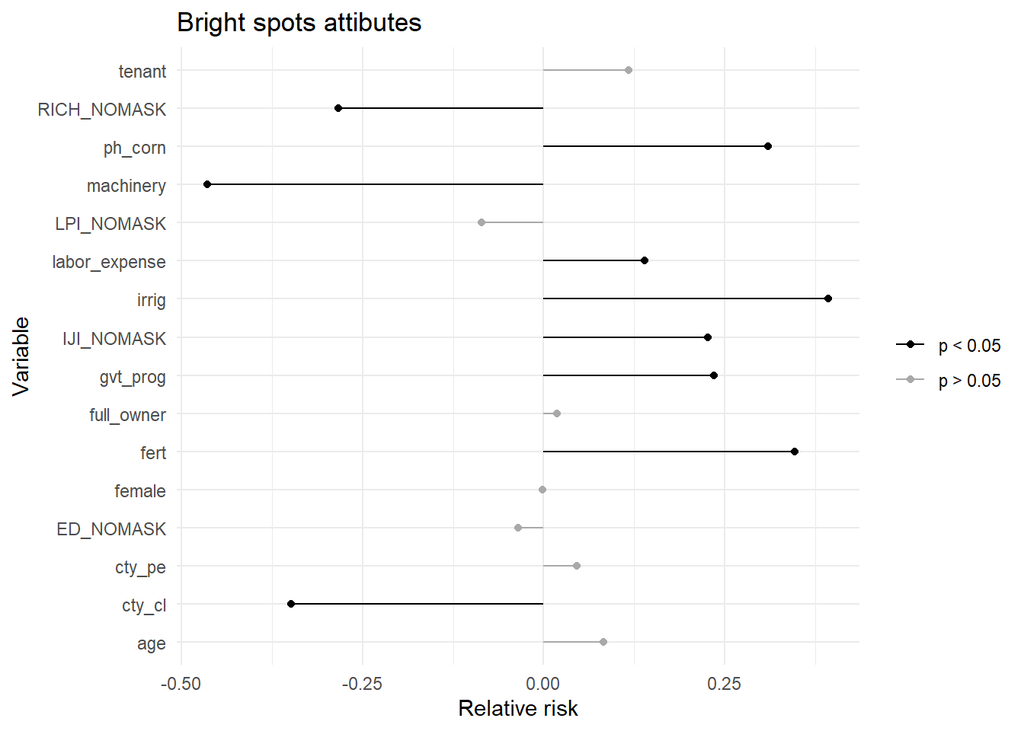

```r
# plot deviations from 1 by variable rather than absolute values for comparison ?
# order lollipops
eff$Bright_Delta <- eff$Bright - 1
eff$Dark_Delta <- eff$Dark - 1

eff <- eff %>%
  filter(Variable != "(Intercept)") %>%
  arrange(desc(Bright_Delta))

ggplot() +
  geom_segment(data = eff, aes(x = 0, y = Variable, xend = Bright_Delta, yend = Variable, color = Bright_S)) +
  geom_point(data = eff, aes(x = Bright_Delta, y = Variable, color = Bright_S)) +
  scale_color_manual(values = c("black", "#A9A9A9")) +
  theme_minimal() +
  theme(legend.title = element_blank()) +
  xlab("Relative risk") +
  ggtitle("Bright spots attibutes")
```

Showing SD, but not entirely the same thing as significance:

```r
eff$Bright_Delta <- eff$Bright - 1
eff$Dark_Delta <- eff$Dark - 1

eff <- eff %>%
  filter(Variable != "(Intercept)") %>%
  arrange(desc(Bright_Delta))

ggplot(data = eff) +
  # geom_segment(data = eff, aes(x = 0, y = Variable, xend = Bright_Delta, yend = Variable, color = Bright_S)) +
  geom_errorbarh(width = 0, aes(xmin = Bright - SE_BS, xmax = Bright + SE_BS, y = Variable)) +
  geom_point(data = eff, aes(x = Bright, y = Variable, color = Bright_S)) +
  scale_color_manual(values = c("black", "#A9A9A9")) +
  theme_minimal() +
  theme(legend.title = element_blank()) +
  xlab("Relative risk") +
  ggtitle("Bright spots attributes")
```

[output not shown]

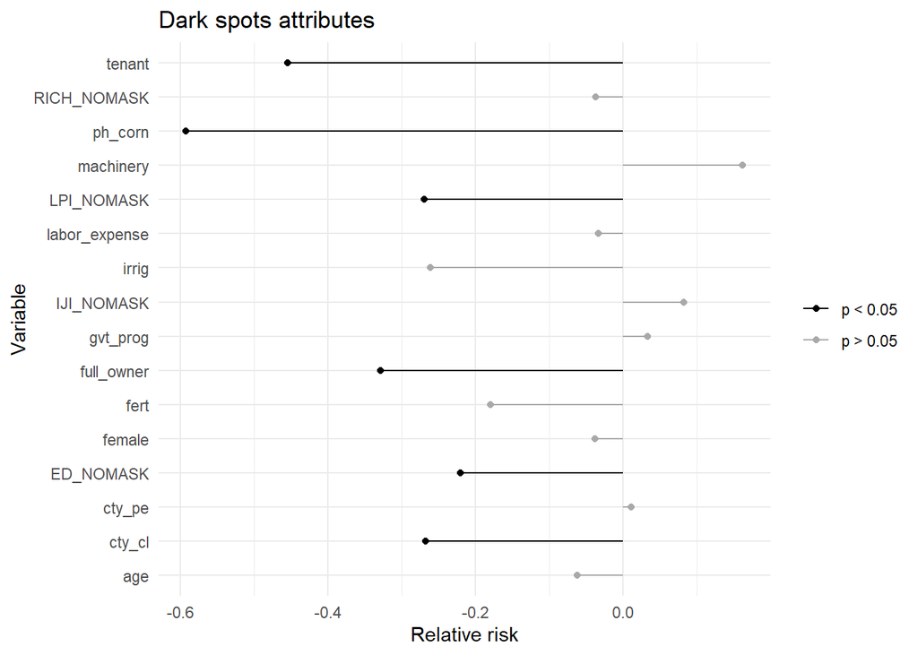

```r
ggplot() +
  geom_segment(data = eff, aes(x = 0, y = Variable, xend = Dark_Delta, yend = Variable, color = Dark_S)) +
  geom_point(data = eff, aes(x = Dark_Delta, y = Variable, color = Dark_S)) +
  scale_color_manual(values = c("black", "#A9A9A9")) +
  theme_minimal() +
  theme(legend.title = element_blank()) +
  xlab("Relative risk") +
  ggtitle("Dark spots attributes")
```

Performance on held-out data and overall model fit statistics:

```r
prediction_scores <- predict(ml_out, ho, "probs")
prediction_class <- predict(ml_out, ho)

# confusion matrix
table(prediction_class, ho$BS_CAT)
```

```
##
## prediction_class Average Bright Dark
##          Average    1715    111  101
##          Bright        3      3    0
##          Dark          0      0    0
```

```r
# misclassification error
mean(as.character(prediction_class) != as.character(ho$BS_CAT), na.rm=T)
```

```
## [1] 0.1112261
```

```r
# pseudo R2, see this: https://www.rdocumentation.org/packages/DescTools/versions/0.99.19/topics/PseudoR2
library(DescTools)
PseudoR2(ml_out, which = "all")
```

```
##        McFadden     McFaddenAdj        CoxSnell      Nagelkerke
##       0.2317556       0.2198071       0.2065731       0.3270911
##   AldrichNelson VeallZimmermann           Efron McKelveyZavoina
##              NA              NA              NA              NA
##            Tjur             AIC             BIC          logLik
##              NA    4440.1586894    4666.1982188   -2186.0793447
##         logLik0              G2
##   -2845.5517641    1318.9448389
```

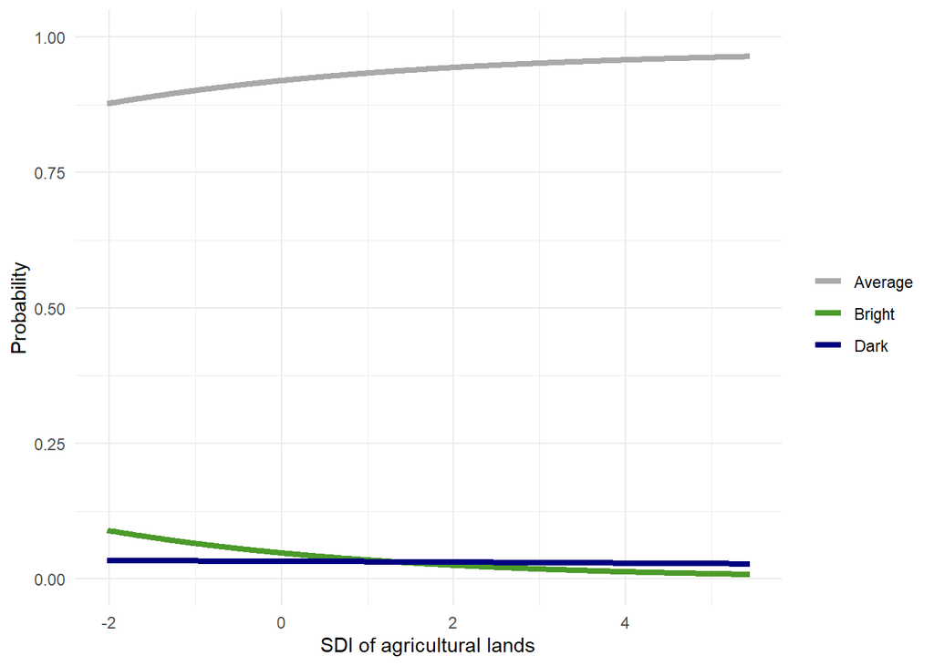

```r
# reproduces effects plot but more transparent

prob_plot <- function(voi, xlab, n = 500) {
  t <- rep(seq(min(train[,voi], na.rm=T),
             max(train[,voi], na.rm=T), length.out = n), each=3)
  tm <- as.data.frame.list(colMeans(train %>% select(-c(BS_CAT)), na.rm = T))
  tm <- do.call("rbind.data.frame", replicate(length(t), tm, simplify=F))
# tm$BS_CAT <- rep(c("Dark", "Average", "Bright"), n)
  tm[,voi] <- t

  pd <- cbind.data.frame(tm, predict(ml_out, newdata = tm, type = "probs", se = T))

  sub <- gather(pd, "Category", "Probability", c((ncol(pd)-2):ncol(pd)))
  p <- ggplot(data = sub) +
  geom_line(aes(x = sub[,voi], y = Probability, color = Category), size=1.5) +
  xlab(xlab) +
  theme_minimal() +
  theme(legend.title = element_blank()) +
  scale_color_manual(values = c("#a9a9a9", "#4C9A2A", "#000080"), name = "")   +
  ylim(c(0,1))
  return(p)

}

prob_plot(voi = "RICH_NOMASK", xlab = "SDI of agricultural lands")
```

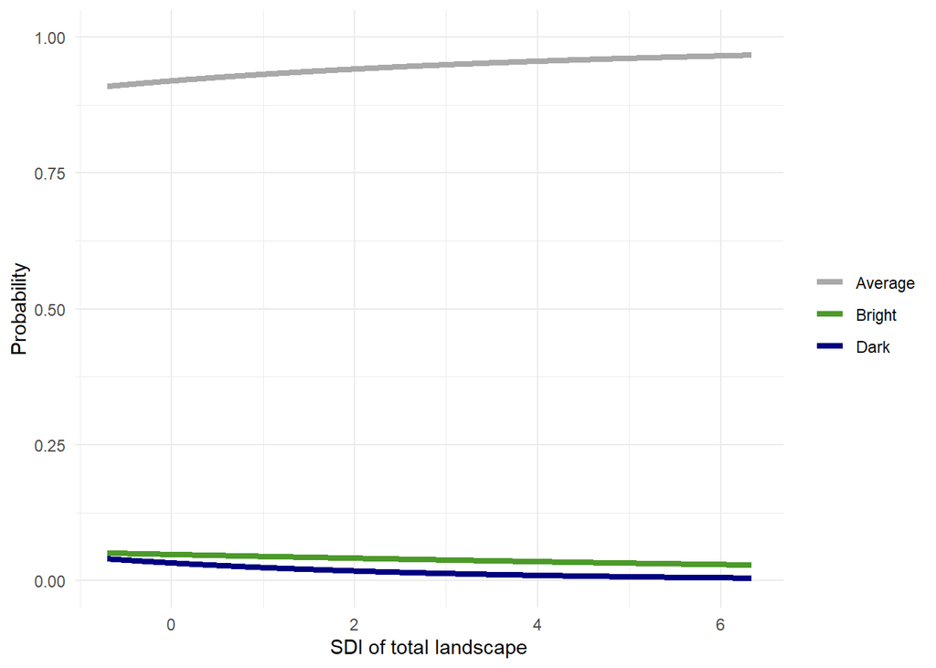

```r
prob_plot("LPI_NOMASK", xlab = "SDI of total landscape")
```

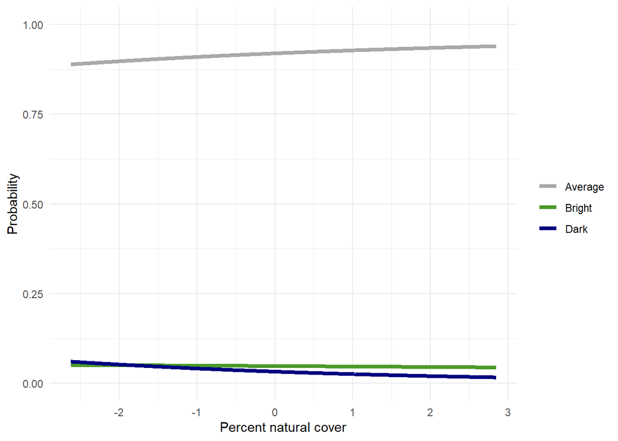

```r
prob_plot("ED_NOMASK", xlab = "Percent natural cover")
```

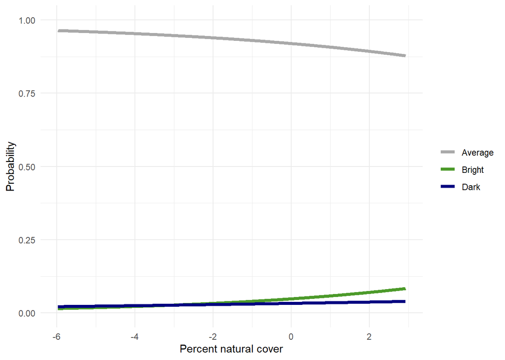

```r
prob_plot("IJI_NOMASK", xlab = "Percent natural cover")
```

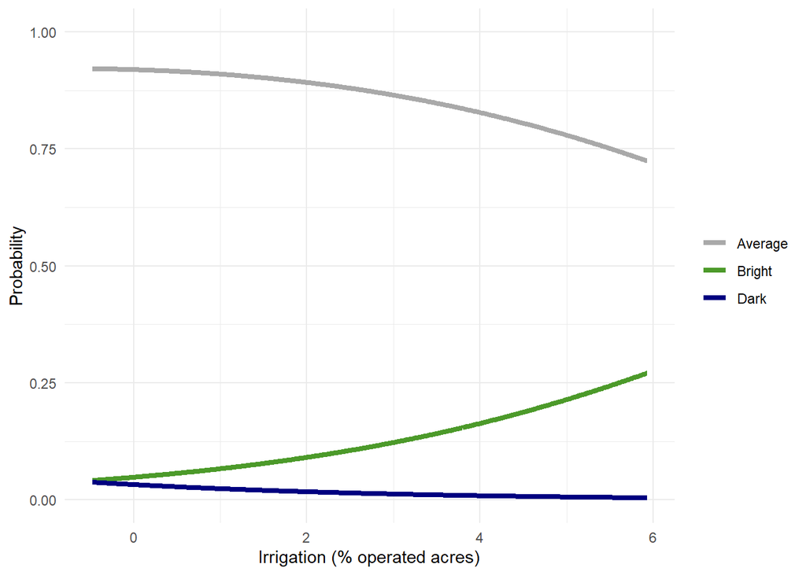

```r
prob_plot("irrig", xlab = "Irrigation (% operated acres)")
```

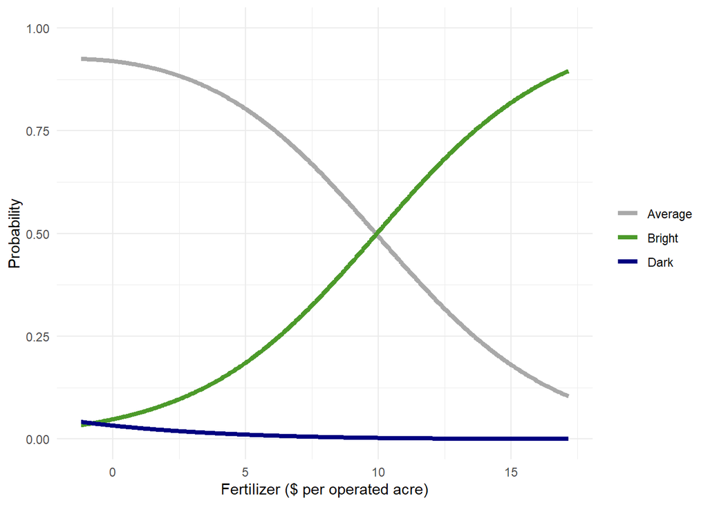

```r
prob_plot("fert", xlab = "Fertilizer ($ per operated acre)")
```

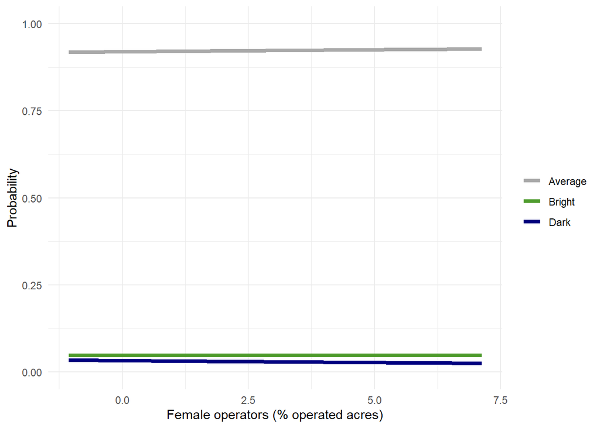

```r
prob_plot("female", xlab = "Female operators (% operated acres)")
```

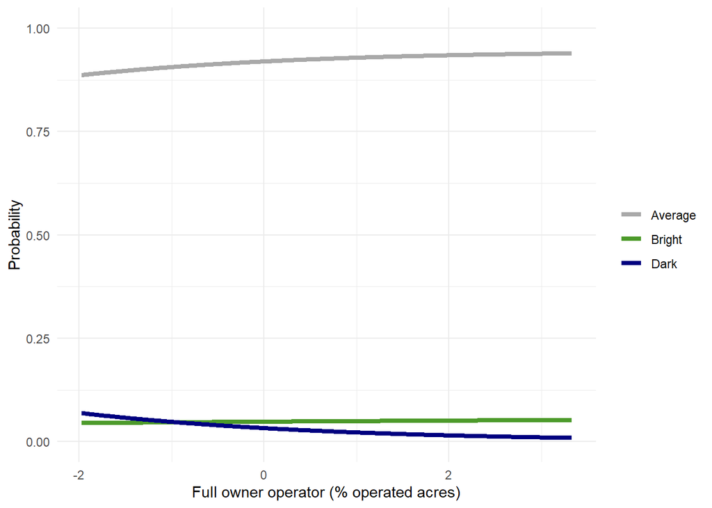

```r
prob_plot("full_owner", xlab = "Full owner operator (% operated acres)")
```

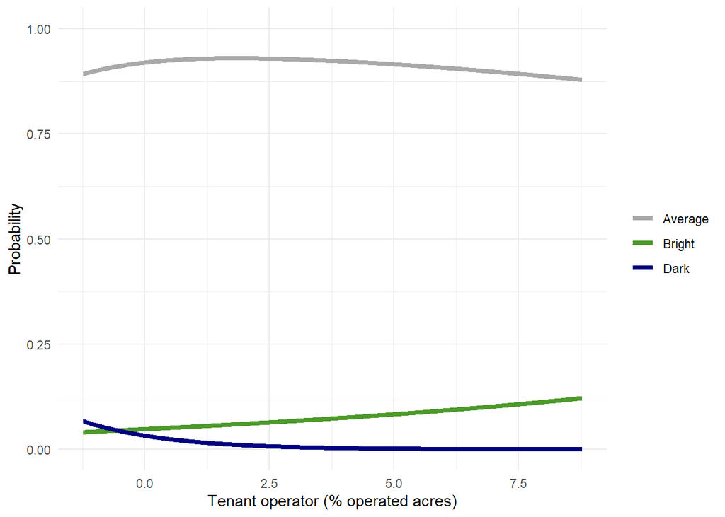

```r
prob_plot("tenant", xlab = "Tenant operator (% operated acres)")
```

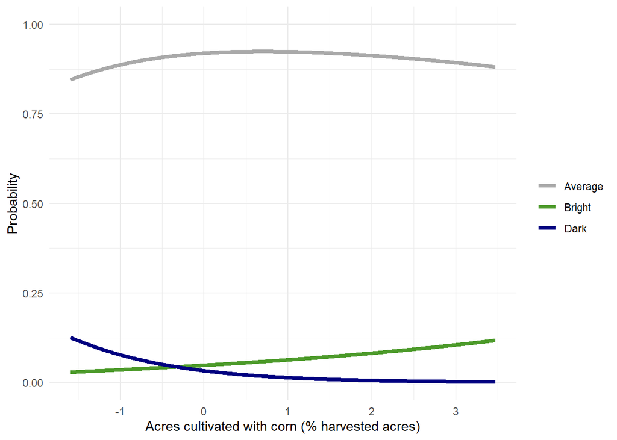

```r
prob_plot("ph_corn", xlab = "Acres cultivated with corn (% harvested acres)")
```

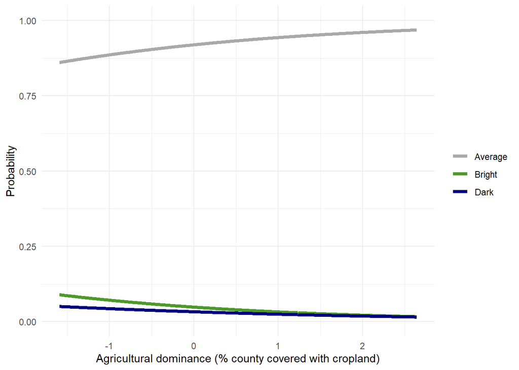

```r
prob_plot("cty_cl", xlab = "Agricultural dominance (% county covered with cropland)")
```

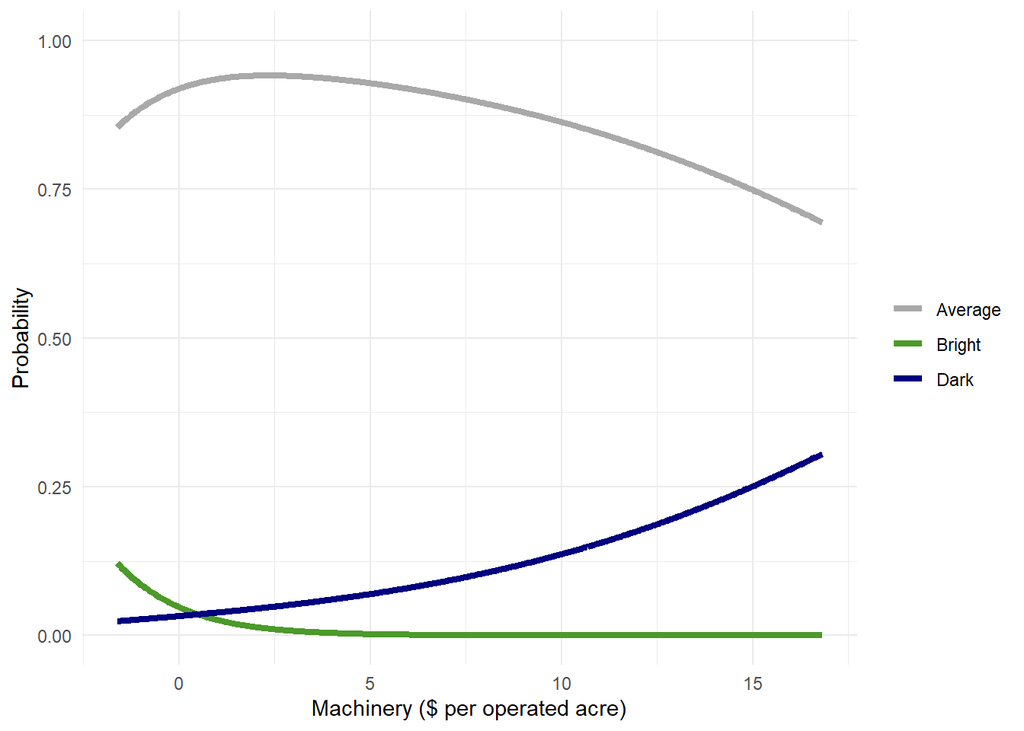

```r
prob_plot("machinery", xlab = "Machinery ($ per operated acre)")
```

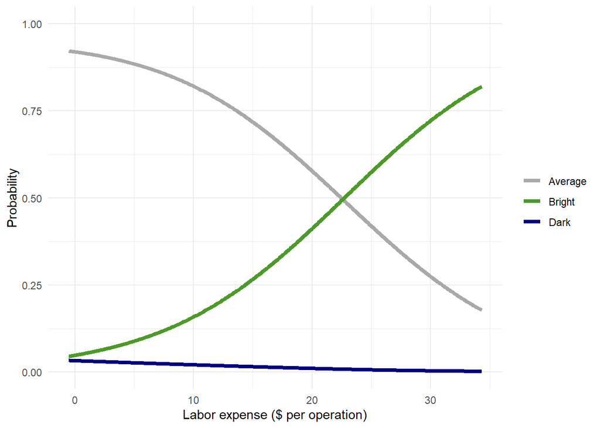

```r
prob_plot("labor_expense", xlab = "Labor expense ($ per operation)")
```

Here’s another interesting way to do the same thing, but not based on simulated data:

```r
# another interesting way to visualize results
# https://thomasleeper.com/Rcourse/Tutorials/nominalglm.html
# first create data where the VOI with simulated range of VOI
voi <- "SDI_NOMASK"
xlab <- "SDI_NOMASK"

newdata <- mlData %>% select(-c(voi)) %>% mutate(!!voi := seq(min(mlData[,voi]), max(mlData[,voi]), length.out = nrow(mlData)))

p1 <- predict(ml_out, newdata, type = "class")
p2 <- predict(ml_out, newdata, type = "probs")

plot(NA, xlim = c(min(mlData[,voi]), max(mlData[,voi])), ylim = c(0, 1), xlab = xlab, ylab = "Predicted Probability")
lines(newdata[,voi], p2[, 1], col = "red", lwd = 2)
lines(newdata[,voi], p2[, 2], col = "blue", lwd = 2)
lines(newdata[,voi], p2[, 3], col = "green", lwd = 2)
# some text labels help clarify things:
text(9, 0.75, "y==1", col = "red")
text(6, 0.4, "y==3", col = "green")
text(5, 0.15, "y==2", col = "blue")
```

### Multinom + nonactionable

```r
vd <- nulli %>%
  select(-c(STATE_FIPS, YIELD, county, LRR, ID,ECO,
            STATE, COUNTY_MEAN, REGION_MEAN, DIFF, BS_CAT, GEOID, YEAR)) %>%
  select(-c(SIDI_AGMASK, BPD_AGMASK, BPD_NOMASK, IJI_AGMASK,
            MODE_AGMASK, MODE_NOMASK, SE_NOMASK, SE_AGMASK, PERC_NATURAL_COVER, SDI_NOMASK, SDI_AGMASK,
            RPR_NOMASK, RPR_AGMASK, SIDI_NOMASK, RICH_AGMASK)) %>%
  select(-c(manure_acres, insur_acres, labor_n, acres_per_op, insur_op, exp, occup, PERC_IRR)) %>%
  select(-c(perc_cl, perc_clp, perc_o, perc_p, perc_wle, perc_pe, perc_t, cty_al, cty_clp,
            cons_wetlands, cons_wet_acres)) %>%
  select(-c(herb_acres, comm_sales, crop_sales, insect_acres, income_farm, part_owner, fert_acres, income, chem)) %>%
  select(-c( male)) %>%
  mutate(BS_BIN = as.factor(ifelse(nulli$BS_CAT == "Bright Spot", 1, 0)),
         DS_BIN = as.factor(ifelse(nulli$BS_CAT == "Dark Spot", 1, 0)))

mlData <- vd %>% select(-c(BS_BIN, DS_BIN))

# create categorical predictor
mlData$BS_CAT <- ifelse(vd$BS_BIN == 1, "Bright", NA)
mlData$BS_CAT <- ifelse(vd$DS_BIN == 1, "Dark", mlData$BS_CAT)
mlData$BS_CAT[is.na(mlData$BS_CAT)] <- "Average"
mlData$BS_CAT <- as.factor(mlData$BS_CAT)
# set baseline
mlData$BS_CAT <- relevel(mlData$BS_CAT, ref = "Average")

# build training and testing datasets
set.seed(1)
random_rn <- sample(nrow(mlData), ceiling(nrow(mlData)*.25))
ho <- mlData[random_rn,]
train <- mlData[-random_rn,]

table(mlData$BS_CAT)
```

```
##
## Average  Bright    Dark
##    7662     498     490
```

```r
library(nnet)
ml_out <- multinom(BS_CAT ~ ., data = train)
summary(ml_out)
```

```
## Call:
## multinom(formula = BS_CAT ~ ., data = train)
##
## Coefficients:
##        (Intercept)           GDD           SDD           TP         EFP
## Bright   -4.211977  0.0004566863  0.0006037044 -0.003737927 0.003658885
## Dark     -2.168585 -0.0002987207 -0.0029970196 -0.011142233 0.009264840
##                EXP CORN_SUIT          age       female        fert
## Bright 0.002004996  1.074500 -0.005708021  0.007550295 0.008025439
## Dark   0.012348092  7.582954  0.016873594 -0.011205756 0.001556214
##          full_owner    gvt_prog       irrig labor_expense     machinery
## Bright -0.002367986 0.021997166 0.026372597   0.001900676 -0.0025043570
## Dark   -0.011515263 0.007427553 0.005762571  -0.002218092 -0.0006152049
##             tenant      cty_cl     ph_corn    ED_NOMASK IJI_NOMASK
## Bright  0.01018542 -0.02094429  0.01542929 -0.002194885 0.04380227
## Dark   -0.08024294 -0.03641202 -0.08177502 -0.003318588 0.04234417
##         LPI_NOMASK RICH_NOMASK       cty_pe
## Bright -0.00441645 -0.04283757 -0.001297096
## Dark   -0.01525846  0.01072269  0.020411805
##
## Std. Errors:
##         (Intercept)          GDD          SDD         TP        EFP
## Bright 0.0002070609 0.0002334994 0.0007395796 0.01172588 0.01171896
## Dark   0.0002371202 0.0002571074 0.0009532423 0.01235849 0.01235872
##               EXP    CORN_SUIT        age      female        fert
## Bright 0.01176283 0.0001811900 0.01760966 0.008627605 0.003585230
## Dark   0.01237684 0.0001912751 0.01922611 0.010013323 0.006057395
##         full_owner    gvt_prog       irrig labor_expense    machinery
## Bright 0.006533242 0.008307955 0.004355069   0.000811579 0.0006011138
## Dark   0.007105658 0.012280632 0.011034908   0.001570568 0.0006422915
##             tenant      cty_cl     ph_corn   ED_NOMASK IJI_NOMASK
## Bright 0.009704978 0.004328933 0.003951988 0.002182196 0.01390993
## Dark   0.018267223 0.004971228 0.005944799 0.002226947 0.01406210
##         LPI_NOMASK RICH_NOMASK      cty_pe
## Bright 0.006752203  0.01044945 0.005775522
## Dark   0.006564390  0.01275531 0.006465565
##
## Residual Deviance: 4210.552
## AIC: 4302.552
```

```r
ml_exp <- exp(coef(ml_out))
```

Adding significance:

```r
eff <- as.data.frame(t(ml_exp))
eff$Variable <- rownames(eff)

# add p-values, Wald test
z <- summary(ml_out)$coefficients/summary(ml_out)$standard.errors
# two tailed Z-test
p <- (1-pnorm(abs(z), 0, 1)) * 2
p <- as.data.frame(t(p))
colnames(p) <- c("Bright_P", "Dark_P")
p$Variable <- rownames(p)

eff <- merge(eff, p, by = "Variable")
eff$Bright_S <- as.factor(ifelse(eff$Bright_P > 0.05, "p > 0.05", "p < 0.05"))
eff$Dark_S <- as.factor(ifelse(eff$Dark_P > 0.05, "p > 0.05", "p < 0.05"))
```

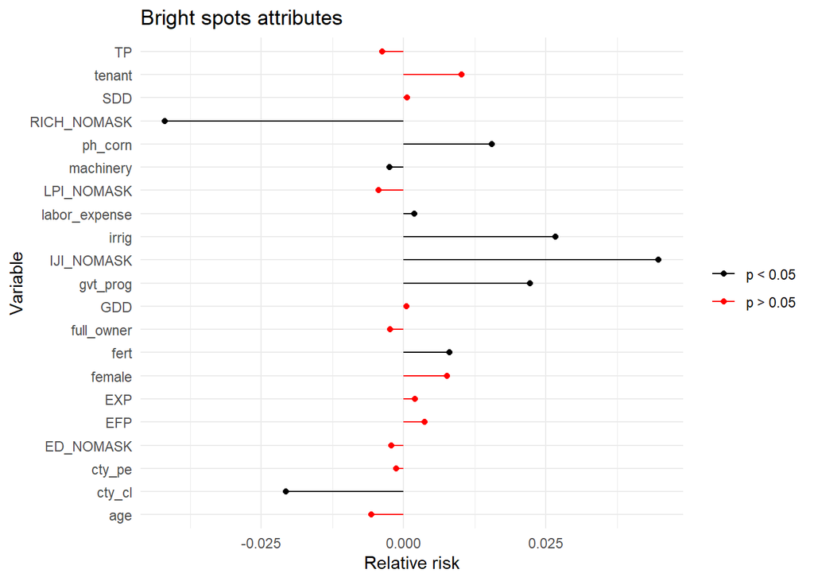

```r
# plot deviations from 1 by variable rather than absolute values for comparison ?
# order lollipops
eff$Bright_Delta <- eff$Bright - 1
eff$Dark_Delta <- eff$Dark - 1

eff <- eff %>%
  filter(!Variable %in% c("(Intercept)", "CORN_SUIT")) %>%
  arrange(desc(Bright_Delta))

ggplot() +
  geom_segment(data = eff, aes(x = 0, y = Variable, xend = Bright_Delta, yend = Variable, color = Bright_S)) +
  geom_point(data = eff, aes(x = Bright_Delta, y = Variable, color = Bright_S)) +
  scale_color_manual(values = c("black", "red")) +
  theme_minimal() +
  theme(legend.title = element_blank()) +
  xlab("Relative risk") +
  ggtitle("Bright spots attributes")
```

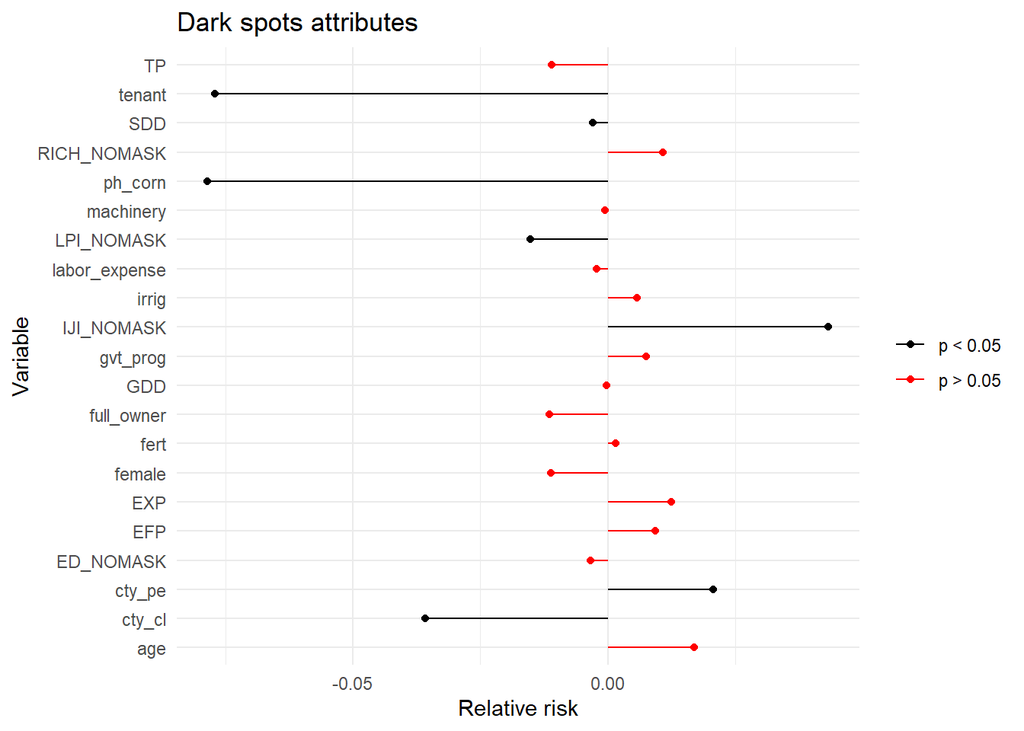

```r
ggplot() +
  geom_segment(data = eff, aes(x = 0, y = Variable, xend = Dark_Delta, yend = Variable, color = Dark_S)) +
  geom_point(data = eff, aes(x = Dark_Delta, y = Variable, color = Dark_S)) +
  scale_color_manual(values = c("black", "red")) +
  theme_minimal() +
  theme(legend.title = element_blank()) +
  xlab("Relative risk") +
  ggtitle("Dark spots attributes")
```

Performance on held-out data and overall model fit statistics:

```r
prediction_scores <- predict(ml_out, ho, "probs")
prediction_class <- predict(ml_out, ho)

# confusion matrix
table(prediction_class, ho$BS_CAT)
```

```
##
## prediction_class Average Bright Dark
##          Average    1713    113   99
##          Bright        2      1    0
##          Dark          3      0    2
```

```r
# misclassification error
mean(as.character(prediction_class) != as.character(ho$BS_CAT), na.rm=T)
```

```
## [1] 0.1122607
```

```r
# pseudo R2, see this: https://www.rdocumentation.org/packages/DescTools/versions/0.99.19/topics/PseudoR2
library(DescTools)
PseudoR2(ml_out, which = "all")
```

```
##        McFadden     McFaddenAdj        CoxSnell      Nagelkerke
##       0.2601518       0.2439863       0.2287524       0.3622102
##   AldrichNelson VeallZimmermann           Efron McKelveyZavoina
##              NA              NA              NA              NA
##            Tjur             AIC             BIC          logLik
##              NA    4302.5524949    4608.3706818   -2105.2762475
##         logLik0              G2
##   -2845.5517641    1480.5510333
```

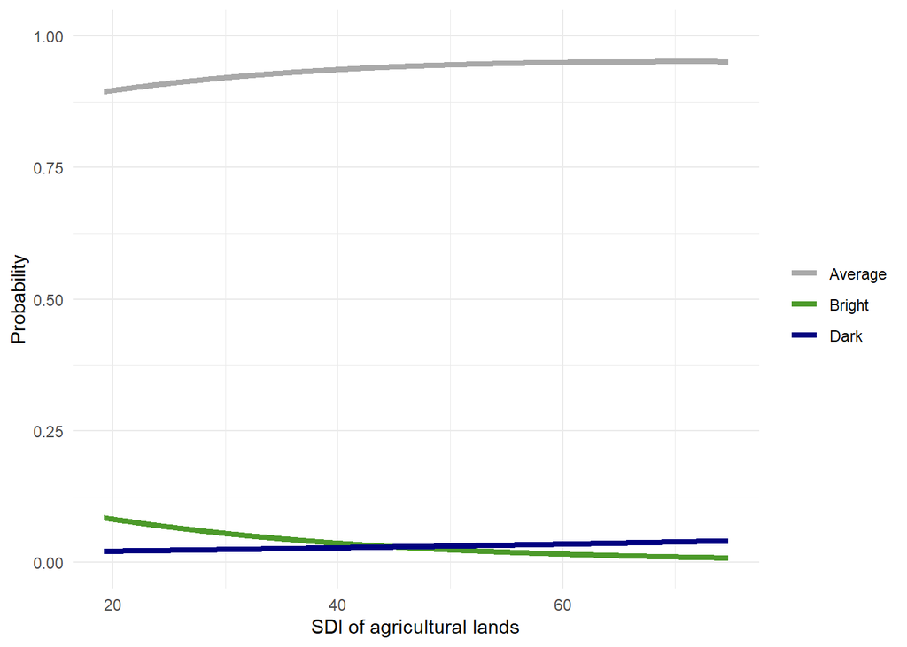

```r
# reproduces effects plot but more transparent

prob_plot <- function(voi, xlab, n = 500) {
  t <- rep(seq(min(train[,voi], na.rm=T),
             max(train[,voi], na.rm=T), length.out = n), each=3)
  tm <- as.data.frame.list(colMeans(train %>% select(-c(BS_CAT)), na.rm = T))
  tm <- do.call("rbind.data.frame", replicate(length(t), tm, simplify=F))
# tm$BS_CAT <- rep(c("Dark", "Average", "Bright"), n)
  tm[,voi] <- t

  pd <- cbind.data.frame(tm, predict(ml_out, newdata = tm, type = "probs", se = T))

  sub <- gather(pd, "Category", "Probability", c((ncol(pd)-2):ncol(pd)))
  p <- ggplot(data = sub) +
  geom_line(aes(x = sub[,voi], y = Probability, color = Category), size=1.5) +
  xlab(xlab) +
  theme_minimal() +
  theme(legend.title = element_blank()) +
  scale_color_manual(values = c("#a9a9a9", "#4C9A2A", "#000080"), name = "")   +
  ylim(c(0,1))
  return(p)

}

prob_plot(voi = "RICH_NOMASK", xlab = "SDI of agricultural lands")
```

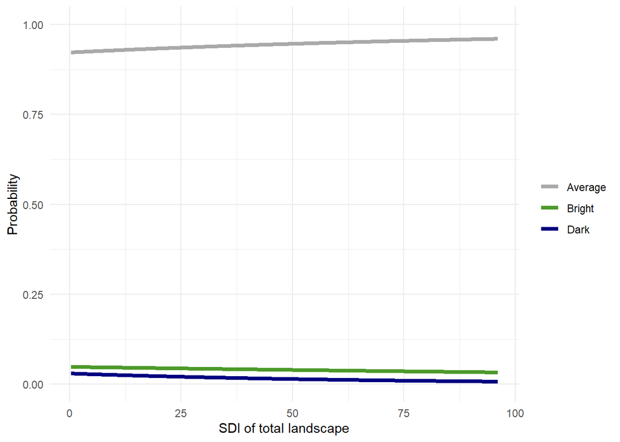

```r
prob_plot("LPI_NOMASK", xlab = "SDI of total landscape")
```

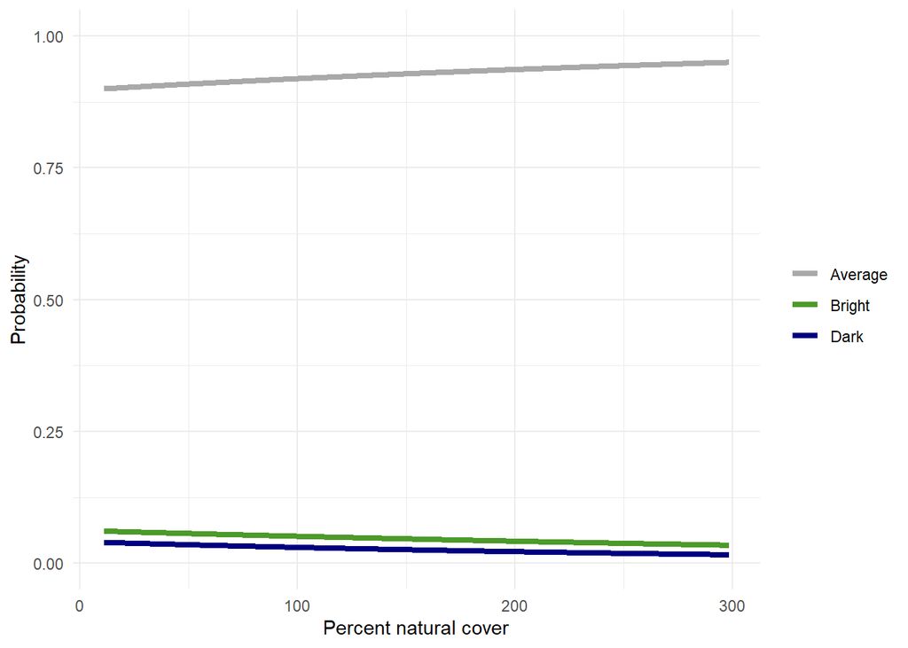

```r
prob_plot("ED_NOMASK", xlab = "Percent natural cover")
```

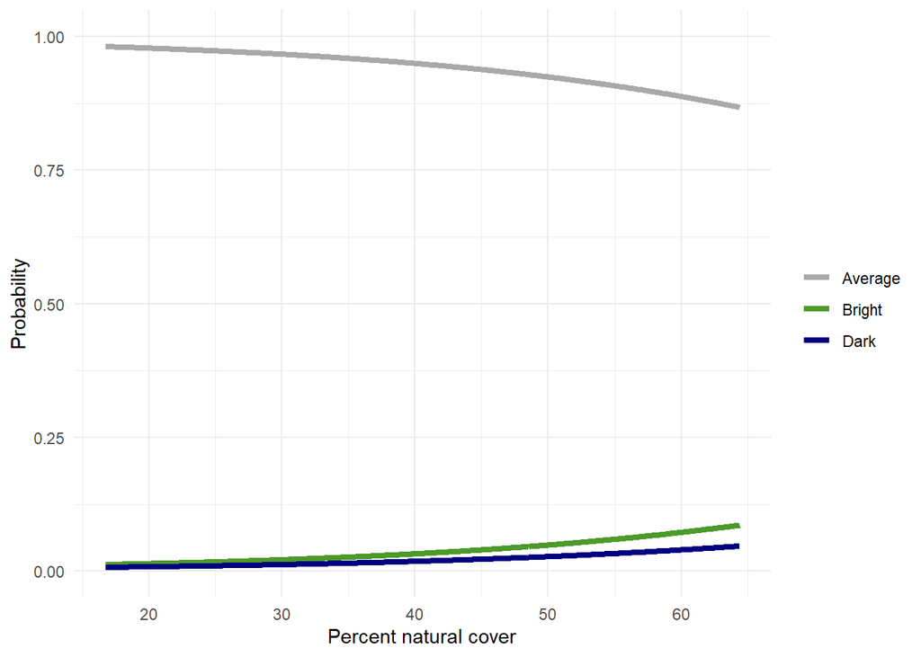

```r
prob_plot("IJI_NOMASK", xlab = "Percent natural cover")
```

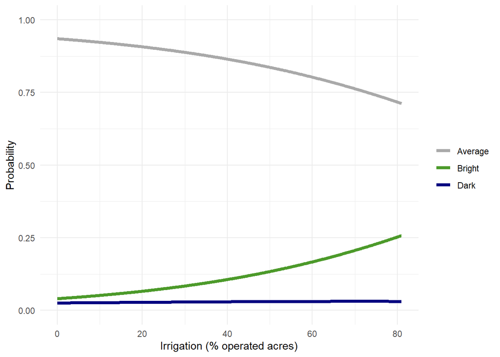

```r
prob_plot("irrig", xlab = "Irrigation (% operated acres)")
```

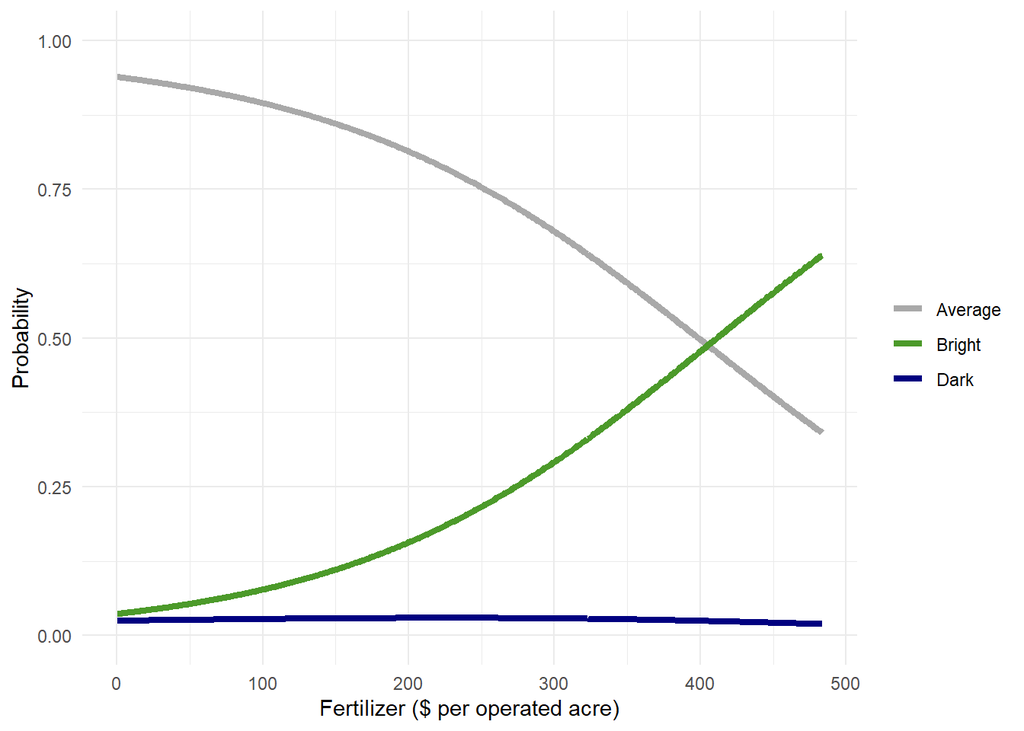

```r
prob_plot("fert", xlab = "Fertilizer ($ per operated acre)")
```

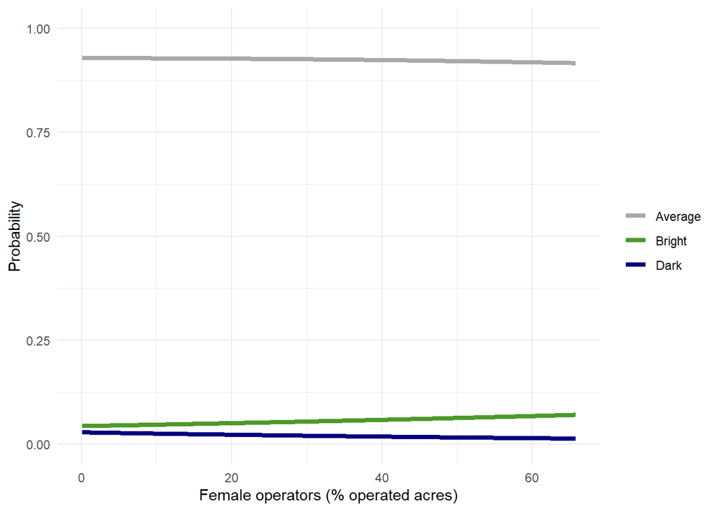

```r
prob_plot("female", xlab = "Female operators (% operated acres)")
```

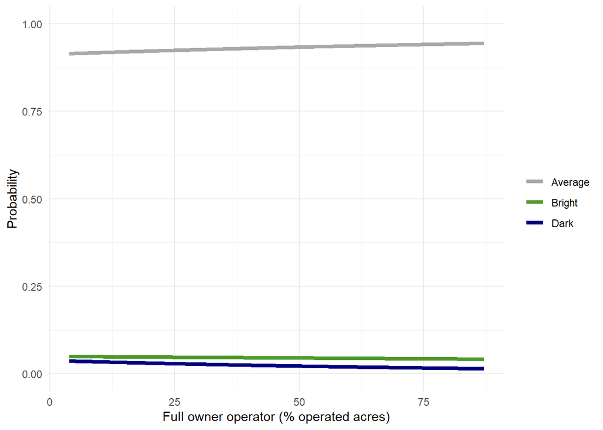

```r
prob_plot("full_owner", xlab = "Full owner operator (% operated acres)")
```

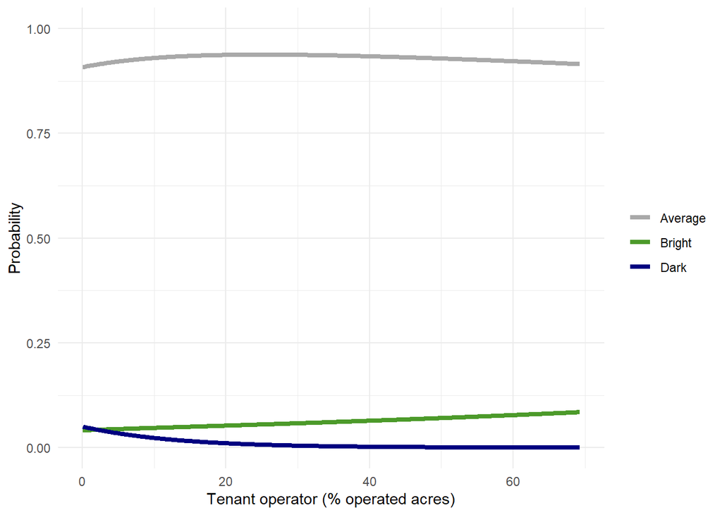

```r
prob_plot("tenant", xlab = "Tenant operator (% operated acres)")
```

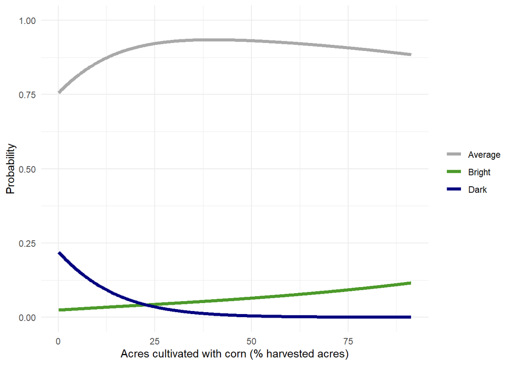

```r
prob_plot("ph_corn", xlab = "Acres cultivated with corn (% harvested acres)")
```

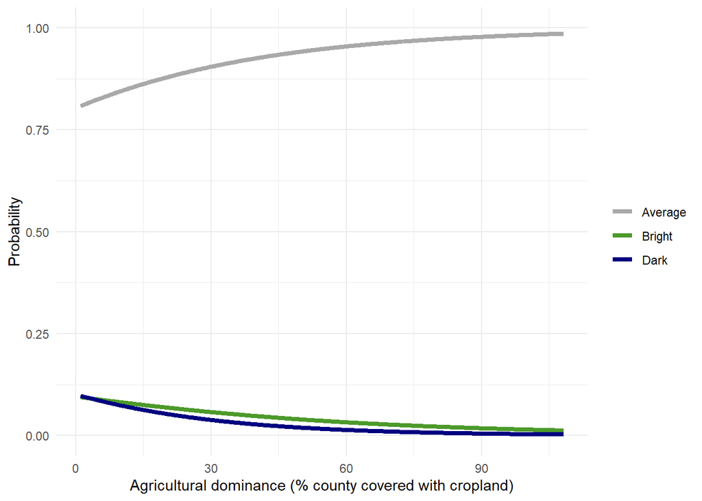

```r
prob_plot("cty_cl", xlab = "Agricultural dominance (% county covered with cropland)")
```

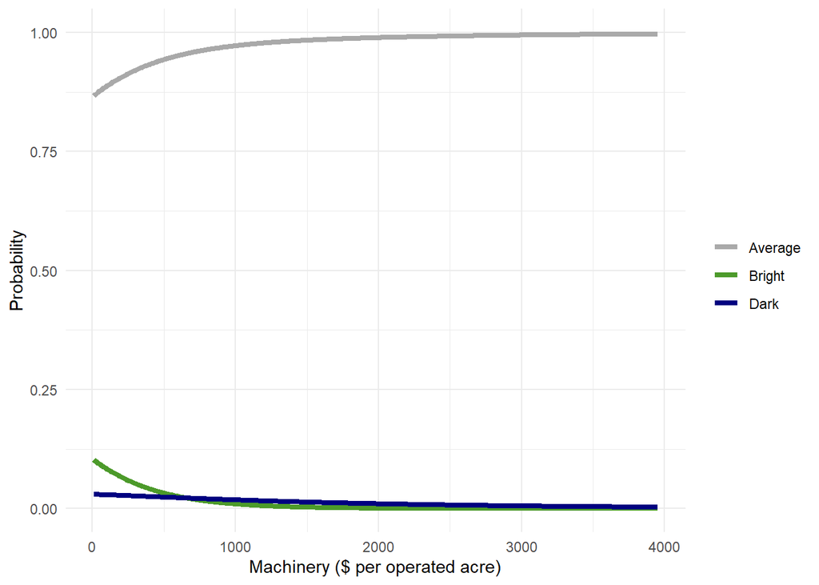

```r
prob_plot("machinery", xlab = "Machinery ($ per operated acre)")
```

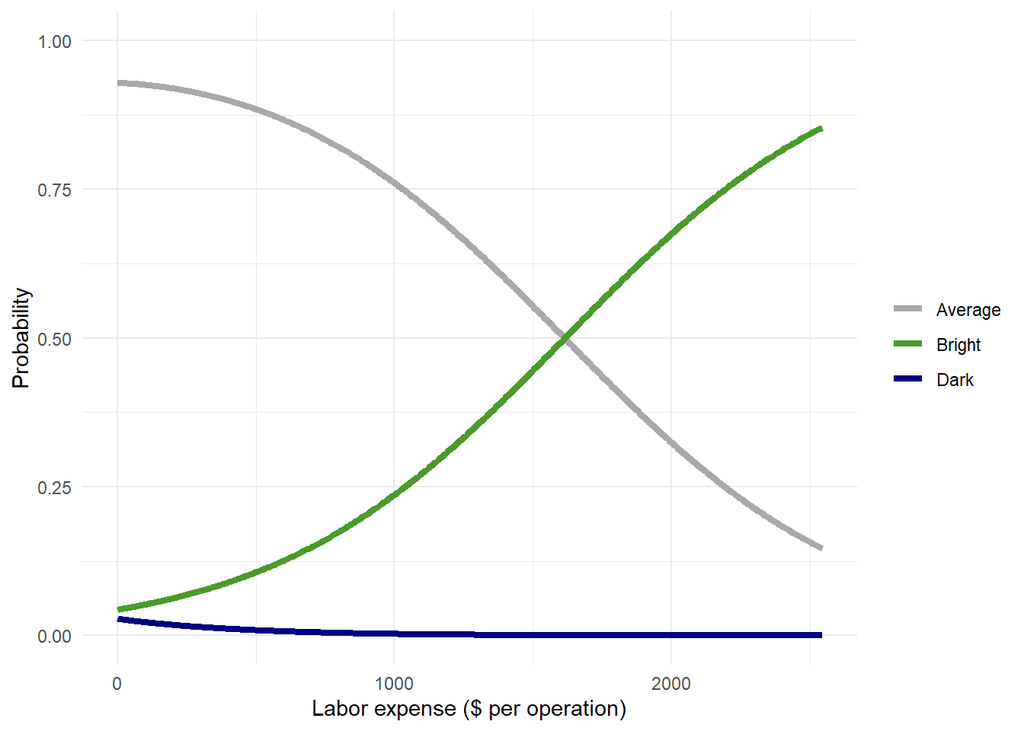

```r
prob_plot("labor_expense", xlab = "Labor expense ($ per operation)")
```

Here’s another interesting way to do the same thing, but not based on simulated data:

```r
# another interesting way to visualize results
# https://thomasleeper.com/Rcourse/Tutorials/nominalglm.html
# first create data where the VOI with simulated range of VOI
voi <- "SDI_NOMASK"
xlab <- "SDI_NOMASK"

newdata <- mlData %>% select(-c(voi)) %>% mutate(!!voi := seq(min(mlData[,voi]), max(mlData[,voi]), length.out = nrow(mlData)))

p1 <- predict(ml_out, newdata, type = "class")
p2 <- predict(ml_out, newdata, type = "probs")

plot(NA, xlim = c(min(mlData[,voi]), max(mlData[,voi])), ylim = c(0, 1), xlab = xlab, ylab = "Predicted Probability")
lines(newdata[,voi], p2[, 1], col = "red", lwd = 2)
lines(newdata[,voi], p2[, 2], col = "blue", lwd = 2)
lines(newdata[,voi], p2[, 3], col = "green", lwd = 2)
# some text labels help clarify things:
text(9, 0.75, "y==1", col = "red")
text(6, 0.4, "y==3", col = "green")
text(5, 0.15, "y==2", col = "blue")
```

### Ordinal logistic regression

Though we’ve built the categories ourselves, my sense if that “Dark”, “Average”, and “High” are *ordinal* rather than *nominal*. This implies that we should use *ordinal* logistic regression rather than the *nominal* approach described above. Nice overview of logit and orginal logistic implementation in R [here](https://www.princeton.edu/~otorres/LogitR101.pdf).

```r
library(foreign)
library(ordinal)

# set up categorical predictor
mlData <- varData
# scale data to address SVD error related to Hess
# scaled <- as.data.frame(scale(mlData %>% select(-c(BS_BIN, DS_BIN))))
mlData$BS_CAT <- ifelse(varData$BS_BIN == 1, "Bright", NA)
mlData$BS_CAT <- ifelse(varData$DS_BIN == 1, "Dark", mlData$BS_CAT)
mlData$BS_CAT[is.na(mlData$BS_CAT)] <- "Average"
mlData$BS_CAT <- ordered(mlData$BS_CAT, levels = c("Dark", "Average", "Bright"))

# build training and testing datasets
set.seed(1)
random_rn <- sample(nrow(mlData), ceiling(nrow(mlData)*.25))
ho <- mlData[random_rn,]
train <- mlData[-random_rn,]

or_out <- clm(BS_CAT ~ ., data = train %>% select(-c(BS_BIN, DS_BIN)))
# or_out <- polr(BS_CAT ~ ., data = train %>% select(-c(BS_BIN, DS_BIN, tenant)), na.action = na.omit, Hess=T) # Hess computes SEs
summary(or_out)
```

```
## formula:
## BS_CAT ~ age + female + fert + full_owner + gvt_prog + irrig + labor_expense + machinery + tenant + cty_cl + ph_corn + ED_NOMASK + IJI_NOMASK + LPI_NOMASK + RICH_NOMASK + cty_pe
## data:    train %>% select(-c(BS_BIN, DS_BIN))
##
##  link  threshold nobs logLik   AIC     niter max.grad cond.H
##  logit flexible  5700 -2240.20 4516.40 8(0)  5.62e-11 4.1e+08
##
## Coefficients:
##                 Estimate Std. Error z value Pr(>|z|)
## age            0.0191686  0.0210590   0.910  0.36270
## female         0.0031151  0.0063036   0.494  0.62118
## fert           0.0077002  0.0028012   2.749  0.00598 **
## full_owner     0.0132739  0.0047916   2.770  0.00560 **
## gvt_prog       0.0181696  0.0071008   2.559  0.01050 *
## irrig          0.0248798  0.0037387   6.655 2.84e-11 ***
## labor_expense  0.0012215  0.0006551   1.864  0.06226 .
## machinery     -0.0015383  0.0003461  -4.445 8.80e-06 ***
## tenant         0.0451771  0.0079590   5.676 1.38e-08 ***
## cty_cl        -0.0026732  0.0033711  -0.793  0.42780
## ph_corn        0.0294322  0.0031147   9.449  < 2e-16 ***
## ED_NOMASK      0.0033153  0.0014894   2.226  0.02602 *
## IJI_NOMASK     0.0185160  0.0101936   1.816  0.06930 .
## LPI_NOMASK     0.0122550  0.0046787   2.619  0.00881 **
## RICH_NOMASK   -0.0222016  0.0073935  -3.003  0.00267 **
## cty_pe         0.0005123  0.0039664   0.129  0.89722
## ---
## Signif. codes:  0 '***' 0.001 '**' 0.01 '*' 0.05 '.' 0.1 ' ' 1
##
## Threshold coefficients:
##                Estimate Std. Error z value
## Dark|Average     0.4167     1.3117   0.318
## Average|Bright   6.6087     1.3219   4.999
## (787 observations deleted due to missingness)
```

```r
# or_coef <- data.frame(coef(or_out))
# library(stargazer)
# stargazer(or_out, type = "text")
```

Relative risk ratios are easier to interpret than the logit coefficients:

```r
or_rr <- exp(coef(or_out))
```

Interpretation: “Keeping all other variables constant, when X1 increases one unit it is 0.97 times more likely to be in a higher category (moving towards bright spots).”

```r
or_pred <- predict(or_out, ho, type = "prob")
```

### ANOVA

Resource [here](https://www.r-bloggers.com/performing-anova-test-in-r-results-and-interpretation/):

Are the variations between the continents means due to true differences about the populations means or just due to sampling variability? To answer this question, ANOVA calculates a parameter called F statistics, which compares the variation among sample means (among different continents in our case) to the variation within groups (within continents).

F statistics = Variation among sample means / Variation within groups

Through the F statistics we can see if the variation among sample means dominates over the variation within groups, or not. In the first case we will have strong evidence against the null hypothesis (means are all equals), while in the second case we would have little evidence against the null hypothesis.

```r
# Make factor variable
varData$BS_CAT <- ifelse(varData$BS_BIN == 1, "Bright", NA)
varData$BS_CAT <- ifelse(varData$DS_BIN == 1, "Dark", varData$BS_CAT)
varData$BS_CAT[is.na(varData$BS_CAT)] <- "Average"
varData$BS_CAT <- as.factor(varData$BS_CAT)

aov <- aov(varData$age ~ varData$BS_CAT)
summary(aov)
```

```
##                  Df Sum Sq Mean Sq F value Pr(>F)
## varData$BS_CAT    2     44  22.064   3.109 0.0447 *
## Residuals      8646  61365   7.097
## ---
## Signif. codes:  0 '***' 0.001 '**' 0.01 '*' 0.05 '.' 0.1 ' ' 1
## 1 observation deleted due to missingness
```

So accept the alternative, that there is a significant relationship between bright spots and age. Or, variation among BS/DS categories much higher than variation within each category. ANOVA doesn’t tell us which groups are different from the others. To determine which groups are different from the others I need to conduct a POST HOC TEST or a post hoc pair comparison (note we can’t perform multiple anova tests one for each pair, as this would increase our error, see family wise error rate for more details) which is designed to evaluate pair means. There are many post hoc tests available for analysis of variance and in my case I will use the Tukey post hoc test, calling with R the function “TukeyHSD” as follows:

```r
tuk <- TukeyHSD(aov)
tuk
```

```
##   Tukey multiple comparisons of means
##     95% family-wise confidence level
##
## Fit: aov(formula = varData$age ~ varData$BS_CAT)
##
## $`varData$BS_CAT`
##                     diff         lwr       upr     p adj
## Bright-Average 0.1556440 -0.13314991 0.4444380 0.4160526
## Dark-Average   0.2761334 -0.01514532 0.5674120 0.0675316
## Dark-Bright    0.1204893 -0.27708490 0.5180635 0.7573423
```

Finally, I can also visualize BS categorical pairs and analyse significant differences by plotting the the “tuk” object in R. Significant differences are the ones which not cross the zero value.

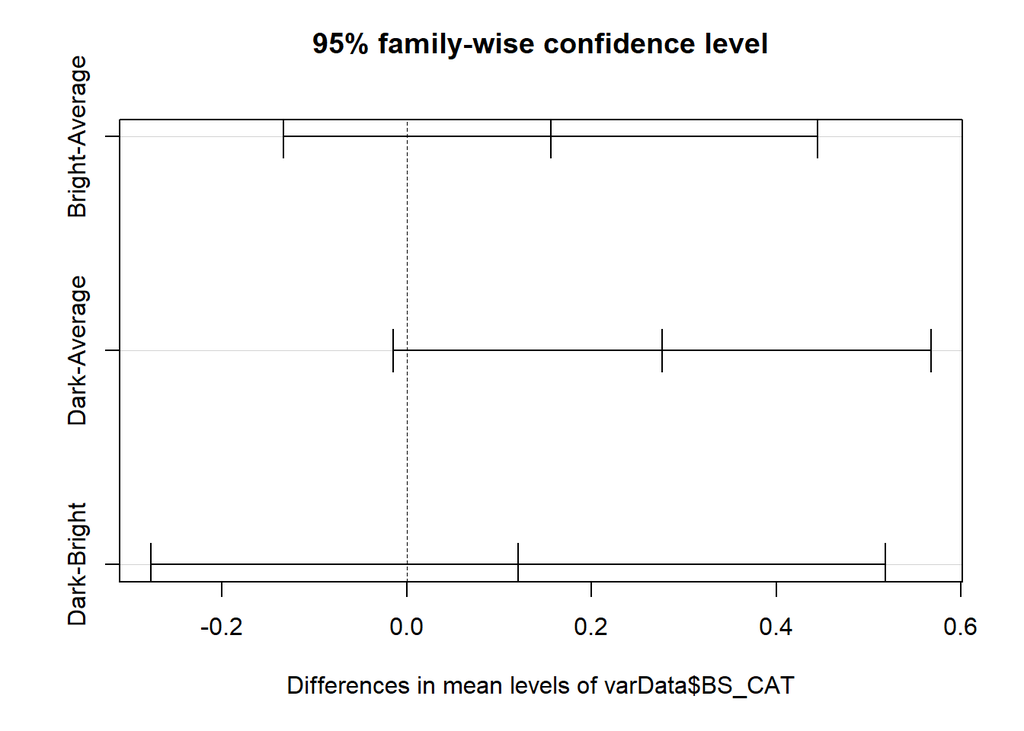

```r
plot(tuk)
```

** Doesn’t resolve the issue of confounding factors though… **

Assumptions of normal distribution and common variance (Levene’s test can check this out). Numeric points are outliers that can affect normality and homogeneity of variance.

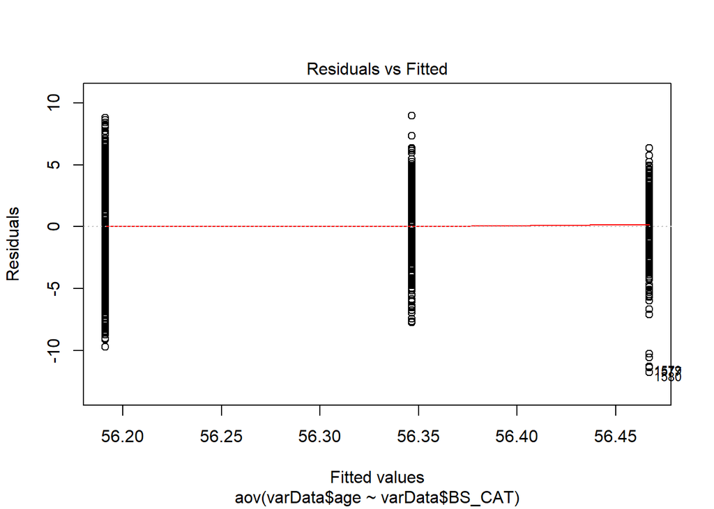

```r
plot(aov, 1)
```

We can also test for equal variance statistically:

```r
library(car)
leveneTest(age ~ BS_CAT, data = varData)
```

```
## Levene's Test for Homogeneity of Variance (center = median)
##         Df F value Pr(>F)
## group    2   0.873 0.4177
##       8646
```

From the output above we can see that the p-value is not less than the significance level of 0.05. This means that there is no evidence to suggest that the variance across groups is statistically significantly different. Therefore, we can assume the homogeneity of variances in the different treatment groups.

If we want to assume unequal variance, do ANOVA this way:

```r
# ANOVA with no assumption of equal variance
oneway.test(age ~ BS_CAT, data=varData)
```

```
##
##  One-way analysis of means (not assuming equal variances)
##
## data:  age and BS_CAT
## F = 3.1269, num df = 2.00, denom df = 737.29, p-value = 0.04444
```

And check the normality assumption:

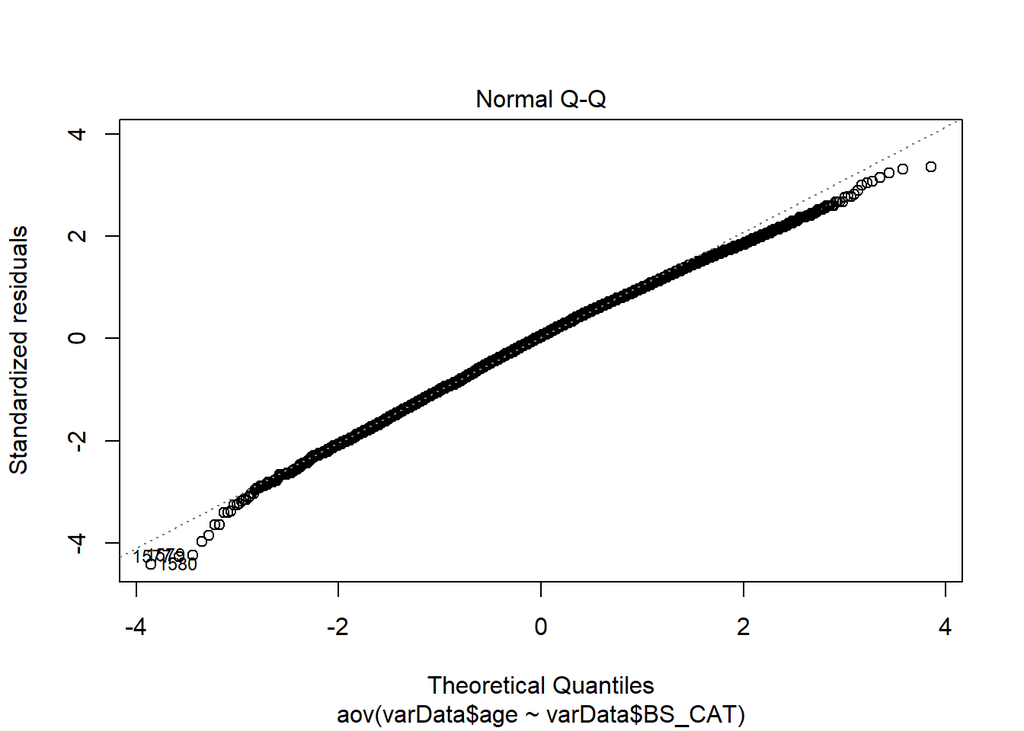

```r
plot(aov, 2)
```

```r
# Run Shapiro-Wilk test
# shapiro.test(x = aov_residuals )
```

Ok, so if we want to do this systematically for all predictors, we’d want to:

1. Check variance assumption
2. Check normality assumption
3. Assuming these are cool, perform ANOVA
4. And to get at nuance, do the Tukey test to see whic categories are different
5. Probably also plot a box and whisker with ANOVA results at the bottom plus Tukey for clarity.

Function to do all of this for a variable is below:

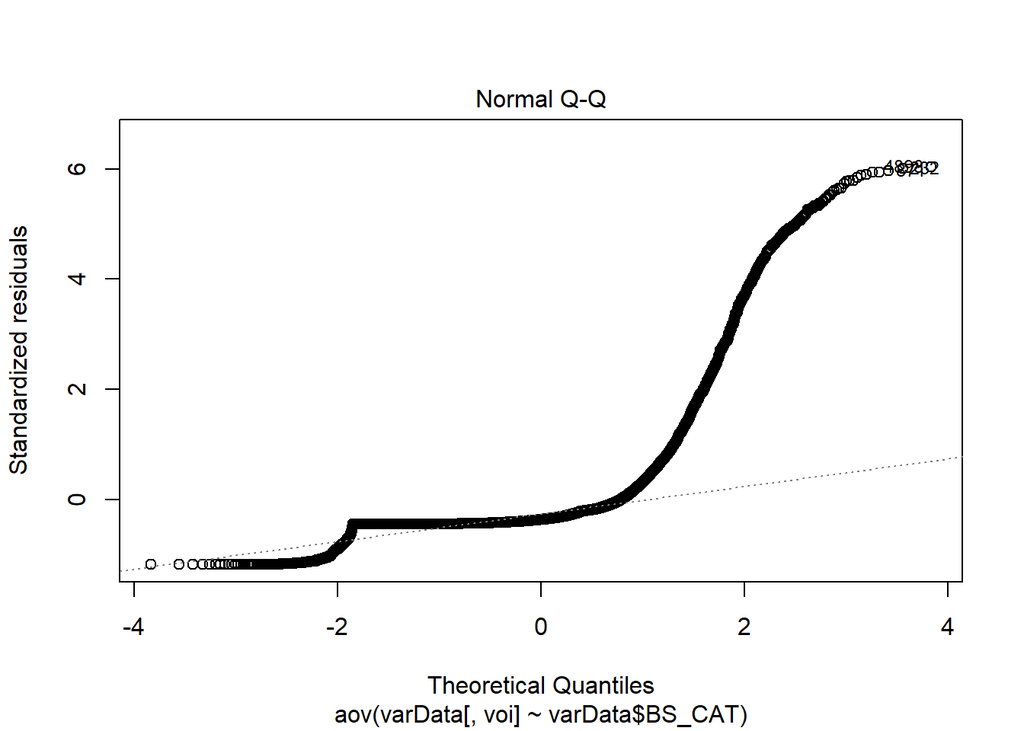

```r
library(Hmisc)
# takes scaled with BS_CAT as input

anova_res <- function(voi) {
  out <- list()
  aov <- aov(varData[,voi] ~ varData$BS_CAT)
  out[["aov"]] <- summary(aov)
  out[["aov_p"]] <- summary(aov)[[1]][["Pr(>F)"]][1]
  out[["var"]] <- leveneTest(age ~ BS_CAT, data = varData)
  p <- plot(aov, 2)
  out[["normal"]] <- p
  out[["tuk"]] <- TukeyHSD(aov)

  plt <- ggplot(data = varData) +
    geom_boxplot(aes(x = varData[,"BS_CAT"], y = varData[,voi])) +
    xlab(paste0("ANOVA p:", round(out[["aov_p"]], 2), "      Variance p:", round(out[["var"]]$`Pr(>F)`[1], 2))) +
    ylab(capitalize(voi)) +
    theme_minimal()
  out[["plot"]] <- plt
  return(out)
}

irr <- anova_res(voi = "irrig")
```

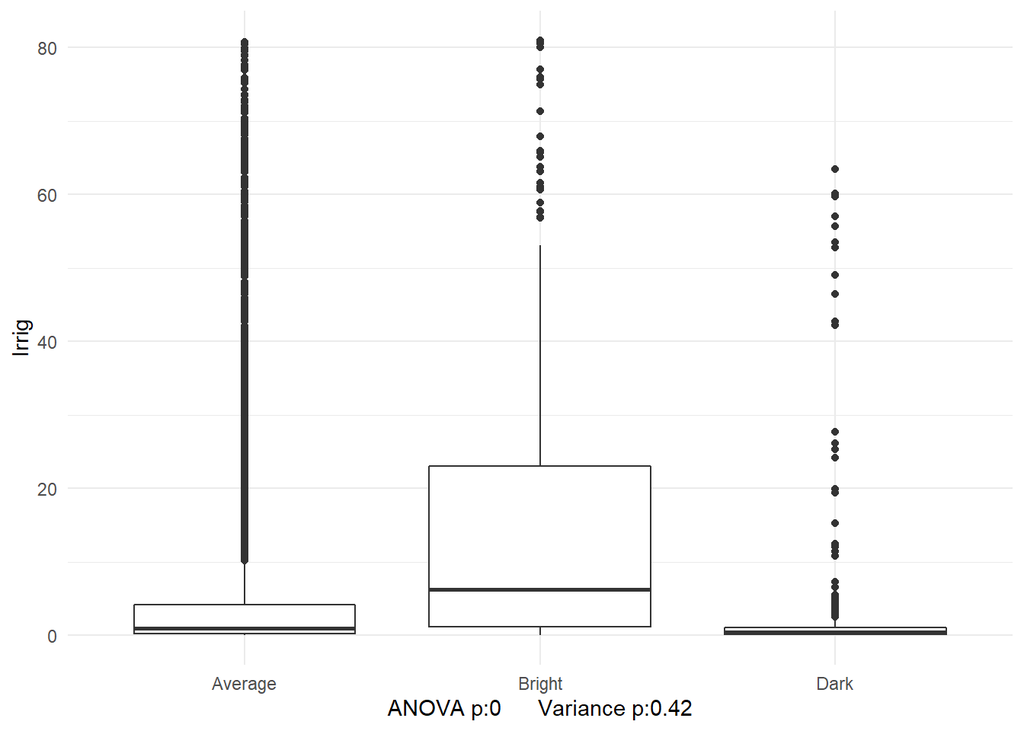

```r
irr$plot
```

```r
irr$tuk
```

```
##   Tukey multiple comparisons of means
##     95% family-wise confidence level
##
## Fit: aov(formula = varData[, voi] ~ varData$BS_CAT)
##
## $`varData$BS_CAT`
##                      diff        lwr        upr p adj
## Bright-Average   9.068457   7.683173  10.453741 0e+00
## Dark-Average    -3.009331  -4.481055  -1.537607 5e-06
## Dark-Bright    -12.077788 -14.038159 -10.117416 0e+00
```

### ETC

#### Discriminant analysis (th=1.5)

Resources and notes: * https://rstudio-pubs-static.s3.amazonaws.com/35817_2552e05f1d4e4db8ba87b334101a43da.html * Model the distribution of the predictors X in each response class Y. Say Y can take on K classifications (3 in our case) * https://www.datascienceblog.net/post/machine-learning/linear-discriminant-analysis/ * Check to make sure data Gaussian. Consider reviewing the univariate distributions of each attribute and using transforms to make them more Gaussian-looking (e.g. log and root for exponential distributions and Box-Cox for skewed distributions). * Consider removing outliers. Standardize data with mean 0 and SD of 1 so that each input variable has the same variance.

Look into: * Flexible Discriminant Analysis (FDA): Where non-linear combinations of inputs is used such as splines. * Regularized Discriminant Analysis (RDA): Introduces regularization into the estimate of the variance (actually covariance), moderating the influence of different variables on LDA.

When true decision boundaries are linear, LDA and logistic are fine. When boundaries are moderately non-linear, QDA will perform better.

##### LDA

PCA finds component axes that maximumze the variance, LDA maximizes the component axes for class separation ([here](https://towardsdatascience.com/linear-discriminant-analysis-lda-101-using-r-6a97217a55a6))

```r
library(MASS)
lda.fit = lda(BS_BIN ~ age + female + tenant + chem + machinery + irrig + labor_expense +
            gvt_prog + ph_corn + cty_cl + SDI_NOMASK + PERC_NATURAL_COVER + RICH_NOMASK, data = train)  # subset = train
lda.fit
```

Group means are averages of each predictor in each class. Coefficients are the linear combinations of predictors used to make the LDA decision rule.

```r
lda.pred <- predict(lda.fit, ho)
table(lda.pred$class, ho$BS_BIN)
mean(lda.pred$class == ho$BS_BIN)
```

```r
library(ROCR)
# roc plot
pred <- prediction(lda.pred$posterior[,2], ho$BS_BIN)
roc <- performance(pred, measure = "tpr", x.measure = "fpr")
auc.train <- performance(pred, measure = "auc")
auc.train <- auc.train@y.values
# Plot
plot(roc)
abline(a=0, b= 1)
text(x = .25, y = .65 ,paste("AUC = ", round(auc.train[[1]],3), sep = ""))
```

##### QDA

Assumes that each class has its own covariance matrix. This is a better option for large datasets, as it tends to have lower bias and a higher variance (see [here](https://towardsdatascience.com/classification-part-2-linear-discriminant-analysis-ea60c45b9ee5)).

Estimates a separate covariance matrix for each class. This can lead to a lot of parameters to estimate.

```r
qda.fit = qda(BS_BIN ~ age + female + tenant + chem + machinery + irrig + labor_expense +
            gvt_prog + ph_corn + cty_cl + SDI_NOMASK + PERC_NATURAL_COVER + RICH_NOMASK, data = train)  # subset = train
qda.fit
```

```r
qda.class = predict(qda.fit, ho)
table(qda.class$class, ho$BS_BIN)
mean(qda.class$class == ho$BS_BIN)
```

#### LASSO regression

- Resource referenced throughout found [here](https://eight2late.wordpress.com/2017/07/11/a-gentle-introduction-to-logistic-regression-and-lasso-regularisation-using-r/)

```r
set.seed(1)
random_rn <- sample(nrow(varData), ceiling(nrow(varData)*.25))
ho <- varData[random_rn,]
train <- varData[-random_rn,]

library(glmnet)
s <- train %>% select(-c(DS_BIN))
x <- model.matrix(s$BS_BIN ~ ., s)
y <- ifelse(s$BS_BIN == "1", 1, 0)
cv.out <- cv.glmnet(x,y,alpha=1, family="binomial", type.measure = "mse") # automatically performs grid search to find best value lambda
plot(cv.out)
```

```r
#min value of lambda
lambda_min <- cv.out$lambda.min
#best value of lambda
lambda_1se <- cv.out$lambda.1se
#regression coefficients with lse
coef(cv.out,s=lambda_1se)
#regression coefficients with lambda.min
```

```r
#get test data
x_test <- model.matrix(BS_BIN ~ ., ho %>% select(-c(DS_BIN)))
#predict class, type=”class”
lasso_prob <- predict(cv.out, newx = x_test, s=lambda_1se, type = "response")

#translate probabilities to predictions
lasso_predict <- rep(0,nrow(ho))
lasso_predict[lasso_prob>.5] <- 1

#confusion matrix
table(pred=lasso_predict,true=ho$BS_BIN)
#accuracy
mean(lasso_predict==ho$BS_BIN)
```

Final model with lambda threshold:

```r
# Final model with lambda.min and with lambda.lse, compare fit, as well as with logistic regression
lasso.model <- glmnet(x, y, alpha = 1, family = "binomial",
                      lambda = lambda_min)
# Make prediction on test data
x.test <- model.matrix(BS_BIN ~., ho %>% select(-c("DS_BIN")))
probabilities <- lasso.model %>% predict(newx = x.test)
predicted.classes <- ifelse(probabilities > 0.5, 1, 0)
# Model accuracy
observed.classes <- ho$BS_BIN
mean(predicted.classes == observed.classes)
```

```r
# Final model with lambda.min and with lambda.lse, compare fit, as well as with logistic regression
lasso.model <- glmnet(x, y, alpha = 1, family = "binomial",
                      lambda = lambda_1se)
# Make prediction on test data
x.test <- model.matrix(BS_BIN ~., ho %>% select(-c("DS_BIN")))
probabilities <- lasso.model %>% predict(newx = x.test)
predicted.classes <- ifelse(probabilities > 0.5, 1, 0)
# Model accuracy
observed.classes <- ho$BS_BIN
mean(predicted.classes == observed.classes)
```

Compare to fit of logistic regression… think through subset selection.